# Breeding Bird Surveys - Cleveland Metroparks

Nathan W. Byer

2023-05-15

# The dataset

Tim Krynak, Erik Shaffer, Jen Brumfield, and other Cleveland Metroparks and affiliated colleagues conducted Breeding Bird Surveys (BBS) at a total of 211 routes between 2017 and 2021. 164 of these routes overlapped with long-term vegetation monitoring efforts through the Cleveland Metroparks Plant Community Assessment Program (PCAP). This provided an excellent opportunity to explore the potential relationships between vegetative composition, landscape structure, and breeding bird ecology and community composition.

# Initial processing

First, we just read in the full BBS dataset. For our purposes, we will remove any BBS observations not paired with PCAP plots. We can also visualize the distribution of survey effort through time.

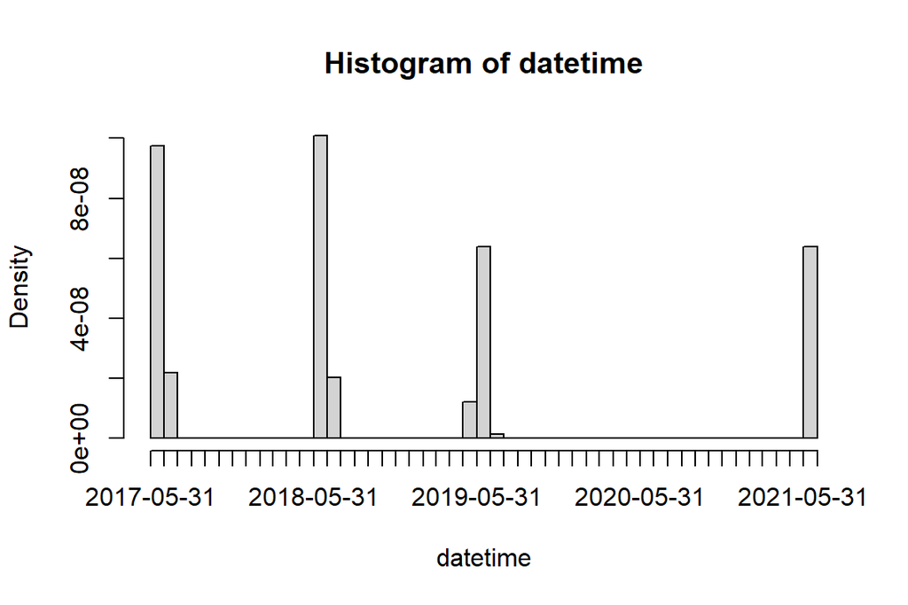

```r
CMP_bbs_pcap_join<-read.csv("G:/NaturalResources/Byer/datasets/BBS/CMP_bbs_pcapjoin_1221covars.csv",header=T)
CMP_bbs_pcap_join_pcaponly<-CMP_bbs_pcap_join[!is.na(CMP_bbs_pcap_join$Plot.ID),]

datetime<-strptime(CMP_bbs_pcap_join_pcaponly$survey_cre,format="%m/%d/%Y %H:%M")
hist(datetime,breaks="months")
```

```r
pcap_1styear_landscape<-read.csv("G:/NaturalResources/Byer/datasets/BBS/pcap_4yr_landscape_variables_revLDI.csv",header=T)
```

Next, we need to start grouping this dataset for downsteram analysis. This involves summarizing counts of each species for each plot. We also replace any NA values in the data frame with zeroes - this will be important for downstream applications, as we want to distinguish between unobserved species at a plot and check (typically coded 0s) and checks that were “skipped” (NAs).

```r
CMP_bbs_pcap_join_pcaponly_pcapsum<-CMP_bbs_pcap_join_pcaponly %>%
  group_by(simp_plot, reservatio,community,species_4_) %>%
  summarise(n=n(),longitude=mean(xcoord), latitude=mean(ycoord),vibifq=mean(as.numeric(vibi_fq_nt)),carex=mean(as.numeric(carex)),
            dicot=mean(as.numeric(dicot)),shade=mean(as.numeric(shade)),shrub=mean(as.numeric(shrub)),
            hydro=mean(as.numeric(hydro)),svp=mean(as.numeric(svp)),
            fqi=mean(as.numeric(fqai)),
            sens_rel=mean(as.numeric(sens)),
            tol_rel=mean(as.numeric(tol)),
            developed=mean(as.numeric(dev)),
            ldi=mean(as.numeric(ldi_3k)),
            small_tree=mean(as.numeric(small_tree)),
            subcanopy_dens=mean(as.numeric(sub_dens)),
            subcanopy_dom=mean(as.numeric(sub_dom)),
            subcanopy_iv=mean(as.numeric(sub_iv)),
            canopy_dens=mean(as.numeric(can_dens)),
            canopy_dom=mean(as.numeric(can_dom)),
            canopy_iv=mean(as.numeric(can_iv)),
            shrub=mean(as.numeric(shrub)),
            monocots=mean(as.numeric(monocots)),
            perc_open=mean(as.numeric(percent_op)),
            slope=mean(slope),
            aspect=mean(aspect),
            twi=mean(twi)
            ) %>%
  spread(species_4_,n) %>%
  replace(is.na(.),0)

names(pcap_1styear_landscape)[names(pcap_1styear_landscape) == 'site.name'] <- 'simp_plot'


CMP_bbs_pcap_join_pcaponly_pcapsum_landscape<-left_join(x = CMP_bbs_pcap_join_pcaponly_pcapsum,y = pcap_1styear_landscape,by="simp_plot")

CMP_bbs_pcap_join_pcaponly_pcapsum<-column_to_rownames(CMP_bbs_pcap_join_pcaponly_pcapsum_landscape,var="simp_plot")
```

Let’s do a bit more processing on this dataset to get it in shape for downstream analyses. First, we will separate out our bird community data.

```r
birdcomm<-CMP_bbs_pcap_join_pcaponly_pcapsum[,30:(132)]

birdcomm[is.na(birdcomm)] <- 0
```

Next, we separate out our PCAP data.

```r
vegecomm<-CMP_bbs_pcap_join_pcaponly_pcapsum[,c(5:14,17:25)]
```

Finally, we will separate out the 1st year landscape covariates. As a quick note, these will not be *strictly* comparable with the 2nd survey landscape covariates, but should be pretty close (~5 years is likely not enough for substantial land cover change).

```r
landcomm<-CMP_bbs_pcap_join_pcaponly_pcapsum[,c(15,16,26,27,28,149,158,159)]

landcomm[is.na(landcomm)] <- 0
```

Since we are using the PCAP dataset as predictors here, we should likely check for correlations between these covariates. I have selected a (semi-)arbitrary cut-off of 0.6 to identify covariates as correlated; we then drop any covariates that are likely redundant.

```r
vegecomm_cor<-cor(vegecomm)

set.seed(12345)
corvar<-findCorrelation(vegecomm_cor,cutoff=0.6)

vegecomm_drop<-vegecomm[,-corvar]
```

We can also check for correlations between the landscape covariates.

```r
cols<-seq(1,8,1)

landcomm[,cols] = apply(landcomm[,cols], 2, function(x) as.numeric(as.character(x)))

landcomm_cor<-cor(landcomm)

set.seed(12345)
corvar_land<-findCorrelation(landcomm_cor,cutoff=0.6)

landcomm_drop<-landcomm[,-corvar_land]
```

We can then check correlations between PCAP and landscape covariates.

```r
landvegcomm_drop<-cbind(vegecomm_drop,landcomm_drop)

landvegcomm_drop_cor<-cor(landvegcomm_drop)

set.seed(12345)
corvar_landveg<-findCorrelation(landvegcomm_drop_cor,cutoff=0.6)
```

No covariates were overly correlated in this dataset, so we can proceed.

Now, we have:

1. a vegecomm dataset - which representing PCAP measurements for each of the 164 BBS/PCAP plots.
2. a birdcomm dataset - representing presence/absence of each bird species for each survey in each plot.
3. a landcomm dataset - representing landscape covariates associated with these PCAP plots.

Note that we are not explicitly considering differences in bird counts (or occupancy, or detectability) through time at this point - we will get to that later. For now, we just want to explore broad associations between these three datasets!

Note as of 6/13/2022 - we will also want to only work with only binary data.

# Community analyses

When working with datasets like these, we first have to acknowledge that these datasets are multivariate - with many possible predictor covariates (for example, plot-level characteristics) and many possible response covariates (for example, presence/absence of species in a plot). Fortunately, community ecology as a field has developed a number of standard approaches for exploring multivariate datasets, of which the most common is (arguably!) ordination. In essence, ordination techniques try to shrink down highly multidimensional datasets into a more manageable number of dimensions - often just a handful (and for initial plotting, typically just two). There are many, many possible ordination tools available for exploring community ecological datasets, and we will explore a few.

## unconstrained ordination

In this section, we will be exploring ways of exploring the bird dataset on its own - basically, without any predictors.

First, we must reclassify our bird community data onto a binary scale - ranging from 0 (no detection) to 1 (detection).

```r
birdcomm_bin<-birdcomm

birdcomm_bin<- birdcomm_bin %>% mutate_if(is.numeric, ~1 * (. >= 1))

BBSMigrants<-read.csv("G:/NaturalResources/Byer/datasets/BBS/BBS Migants.csv",header=T)

BBSMigrants_sub<-BBSMigrants[BBSMigrants$SpeciesCode %in% colnames(birdcomm_bin),]

BBSMigrants_sub_2<-BBSMigrants_sub[order(BBSMigrants_sub$SpeciesCode),]

Residency<-BBSMigrants_sub_2$Residency

color_resid<-Residency

color_resid[color_resid %in% "NE"]<-"#56B4E9"

color_resid[color_resid %in% "M"]<-"#009E73"

color_resid[color_resid %in% "R"]<-"#E69F00"

BBSMigrants_sub$color_resid<-color_resid
```

One of the most common approaches for unconstrained ordination is called Principal Components Analysis (PCA). I have illustrated vegan’s rda() function (which we will use a bit more below!). Out of the available options, I find rda() to be much easier to use, so I tend to use it preferentially. Here is a plot with convex hulls and points colored by reservation.

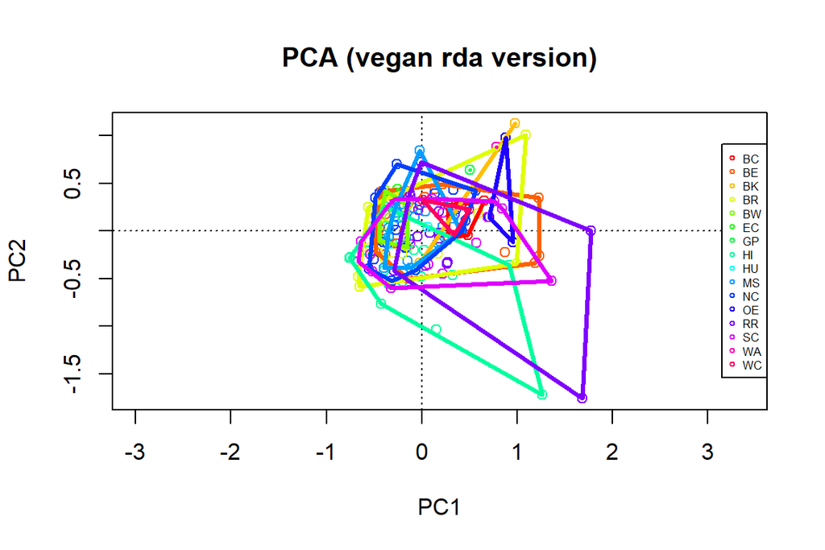

while a bit hard to interpret, plots within Rocky River (RR) seem to be the most variable - and it might be that we see higher diversity in that area. We will see as we proceed if that is true.

### metric multidimensional scaling (Principal Coordinates Analysis)

You can think of this as a distance-based analog to PCA. In this case, since we are using Bray-Curtis distances on binary data (presence/absence), this is equivalent to Sorensen’s index.

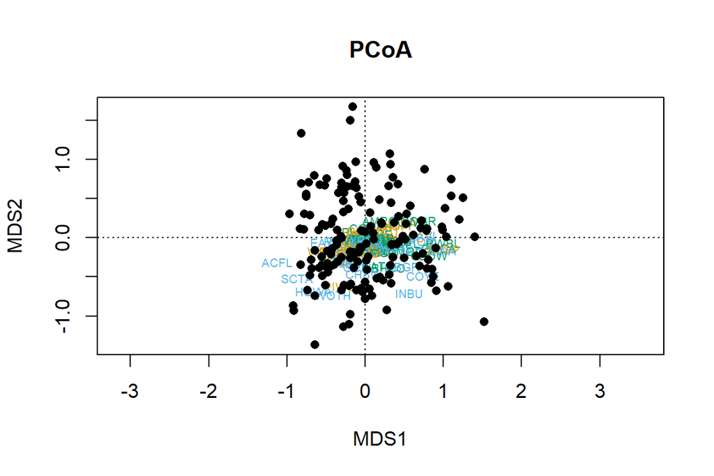

## constrained

Whereas the ordination approaches above were focused on unconstrained ordination - in this case, exploring how species are arranged between sample sites - there is an entire suite of approaches that address how environmental gradients shape community assemblages among sample sites. These are called **constrained** ordination approaches. I am personally a huge proponent of redundancy analysis (RDA) as a flexible constrained ordination approach. Taken from the GUSTA ME tutorial on RDA:

“*RDA can also be considered a constrained version of principal components analysis (PCA), wherein canonical axes - built from linear combinations of response variables - must also be linear combinations of the explanatory variables (i.e. fitted by [multiple linear regression]). The RDA approach generates one ordination in the space defined by the matrix of response variables and another in the space defined by the matrix of explanatory variables.*”

So, in essence, the ordination plot produced will depict an optimal arrangement of environmental axes (RDA1, 2, etc.) that maximally explains variation in the species dataset.

We are going to use stepwise selection to explore which PCAP covariates most explain plot-level differences.

```r
p<-rda(birdcomm_bin~.,vegecomm_drop,scale=T)
fit<-envfit(p,vegecomm_drop,scale=T)
intersetcor(p)
```

```
##                      RDA1         RDA2        RDA3        RDA4         RDA5        RDA6        RDA7          RDA8        RDA9        RDA10        RDA11        RDA12        RDA13
## carex         -0.19888557  0.131586376  0.38928467 -0.20179195  0.037911117 -0.06954034 -0.11765316  0.2580990788 -0.19153828  0.192847145 -0.042753559 -0.120685736 -0.022630018
## dicot         -0.19790895 -0.487597935  0.29759637 -0.17511993  0.058869156  0.11704065 -0.09461204  0.2483376208 -0.07445399 -0.003451971 -0.026689428 -0.016728041 -0.020144535
## shrub         -0.07663118  0.035727921 -0.24968700  0.15067733  0.049844476  0.35612988  0.01766048  0.2939474684 -0.23988630 -0.059079180 -0.063292396 -0.049730439  0.143350901
## hydro         -0.18621081 -0.031152083  0.12293297  0.03963291  0.140765482  0.14689703 -0.01663305 -0.1066921130  0.02937865 -0.045054724 -0.379408272  0.153330359  0.233000162
## svp           -0.39692080 -0.055816614  0.08506936 -0.39517682  0.001802735  0.26657190  0.02677696 -0.0003119226 -0.01900667 -0.054643618 -0.093630788  0.002540716 -0.212894395
## sens_rel      -0.31112534 -0.023456544 -0.19306686 -0.12263433  0.102908203 -0.07694969 -0.29132898  0.1658707525  0.03481945  0.007900273  0.129890474  0.319285137 -0.100965578
## tol_rel        0.48152594  0.013113418  0.21215967 -0.10942388 -0.175263563 -0.14049190  0.17364880  0.2678222960 -0.02013616 -0.201267217 -0.045534265 -0.010683381  0.005940635
## small_tree    -0.05687409 -0.004718276  0.11770849  0.19530130  0.265005842 -0.26552172  0.35134045 -0.0373840911 -0.15014401  0.027455865 -0.040234106  0.177264953 -0.167967553
## subcanopy_dom -0.07626750  0.025895350 -0.02978902  0.03171058  0.341167264 -0.01252776 -0.18046608  0.3196661780  0.21112018 -0.050191931 -0.140894091 -0.182471859 -0.143293540
## canopy_dens   -0.26454307 -0.181548815 -0.20429922 -0.08091113 -0.292485229 -0.31121593 -0.04128952  0.1240905760  0.04258562  0.014511710 -0.189089039 -0.184709682  0.048199552
## canopy_dom    -0.07105491  0.004691516 -0.02339502  0.22184058 -0.199870015  0.12488797  0.14441492  0.0800204755  0.20797662  0.303522381 -0.123484677  0.248039060 -0.081070597
## monocots      -0.56683336 -0.106595112  0.06507582 -0.14164873  0.083467733  0.02239654  0.17558360  0.1490953710  0.05470636  0.054178559  0.198820205 -0.010746840  0.144413061
## perc_open      0.51443401  0.016025956 -0.01572021 -0.41971027  0.172423045  0.05398118  0.07019778  0.1234377456 -0.04714295  0.019049110 -0.008935098  0.042922643  0.095395758
```

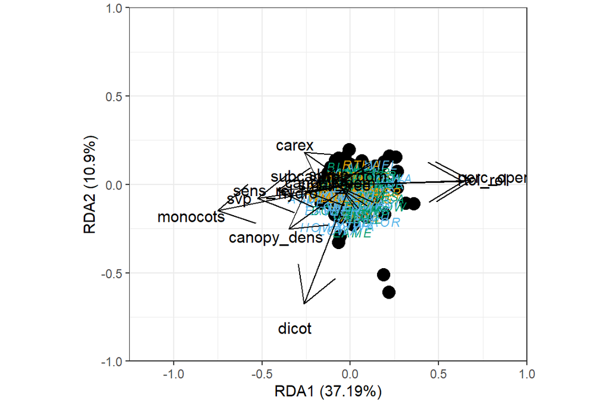

```r
ggord(p,  xlim=c(-1.25,1),ylim = c(-1, 1),txt=4,arrow=TRUE,ptslab=TRUE,addsize=3, size =4,addcol = color_resid)
```

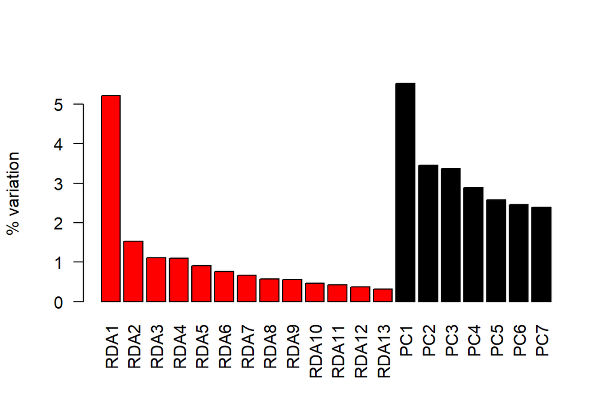

```r
constrained_eig <- p$CCA$eig/p$tot.chi*100
unconstrained_eig <- p$CA$eig/p$tot.chi*100
expl_var <- c(constrained_eig, unconstrained_eig)
barplot (expl_var[1:20], col = c(rep ('red', length (constrained_eig)), rep ('black', length (unconstrained_eig))),
         las = 2, ylab = '% variation')
```

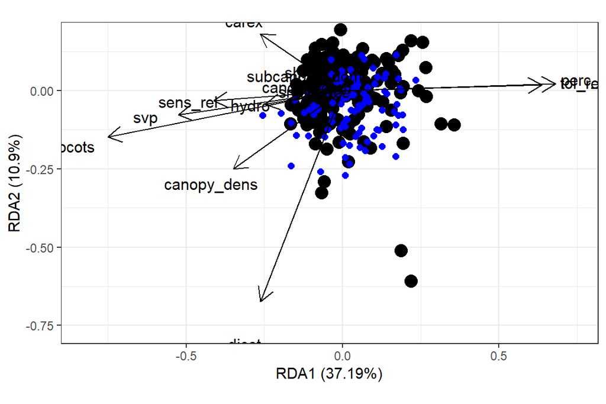

```r
p_0<-rda(birdcomm_bin~1,vegecomm_drop,scale=T)
p_1<-rda(birdcomm_bin~.,vegecomm_drop,scale=T)


ggord(p_1)
```

```r
set.seed(12345)
p_step<- ordistep(p_0, scope = formula(p_1),trace=F)
p_step
```

```
## Call: rda(formula = birdcomm_bin ~ monocots + perc_open + dicot + svp + carex + canopy_dens + tol_rel, data = vegecomm_drop, scale = T)
##
##                Inertia Proportion Rank
## Total         103.0000     1.0000
## Constrained    10.4324     0.1013    7
## Unconstrained  92.5676     0.8987  102
## Inertia is correlations
##
## Eigenvalues for constrained axes:
##  RDA1  RDA2  RDA3  RDA4  RDA5  RDA6  RDA7
## 5.127 1.474 1.092 0.969 0.737 0.567 0.468
##
## Eigenvalues for unconstrained axes:
##   PC1   PC2   PC3   PC4   PC5   PC6   PC7   PC8
## 5.927 3.639 3.597 3.062 2.777 2.598 2.546 2.371
## (Showing 8 of 102 unconstrained eigenvalues)
```

```r
anova(p_step)
```

```
## Permutation test for rda under reduced model
## Permutation: free
## Number of permutations: 999
##
## Model: rda(formula = birdcomm_bin ~ monocots + perc_open + dicot + svp + carex + canopy_dens + tol_rel, data = vegecomm_drop, scale = T)
##           Df Variance      F Pr(>F)
## Model      7   10.432 2.5116  0.001 ***
## Residual 156   92.568
## ---
## Signif. codes:  0 '***' 0.001 '**' 0.01 '*' 0.05 '.' 0.1 ' ' 1
```

```r
anova(p_step,by="term")
```

```
## Permutation test for rda under reduced model
## Terms added sequentially (first to last)
## Permutation: free
## Number of permutations: 999
##
## Model: rda(formula = birdcomm_bin ~ monocots + perc_open + dicot + svp + carex + canopy_dens + tol_rel, data = vegecomm_drop, scale = T)
##              Df Variance      F Pr(>F)
## monocots      1    3.297 5.5556  0.001 ***
## perc_open     1    2.093 3.5269  0.001 ***
## dicot         1    1.155 1.9458  0.003 **
## svp           1    1.187 2.0011  0.002 **
## carex         1    1.013 1.7074  0.002 **
## canopy_dens   1    0.870 1.4660  0.042 *
## tol_rel       1    0.818 1.3785  0.045 *
## Residual    156   92.568
## ---
## Signif. codes:  0 '***' 0.001 '**' 0.01 '*' 0.05 '.' 0.1 ' ' 1
```

```r
anova(p_step,by="axis")
```

```
## Permutation test for rda under reduced model
## Forward tests for axes
## Permutation: free
## Number of permutations: 999
##
## Model: rda(formula = birdcomm_bin ~ monocots + perc_open + dicot + svp + carex + canopy_dens + tol_rel, data = vegecomm_drop, scale = T)
##           Df Variance      F Pr(>F)
## RDA1       1    5.127 8.6397  0.001 ***
## RDA2       1    1.474 2.4839  0.002 **
## RDA3       1    1.092 1.8403  0.041 *
## RDA4       1    0.969 1.6324  0.076 .
## RDA5       1    0.737 1.2416  0.510
## RDA6       1    0.567 0.9550  0.904
## RDA7       1    0.468 0.7883  0.903
## Residual 156   92.568
## ---
## Signif. codes:  0 '***' 0.001 '**' 0.01 '*' 0.05 '.' 0.1 ' ' 1
```

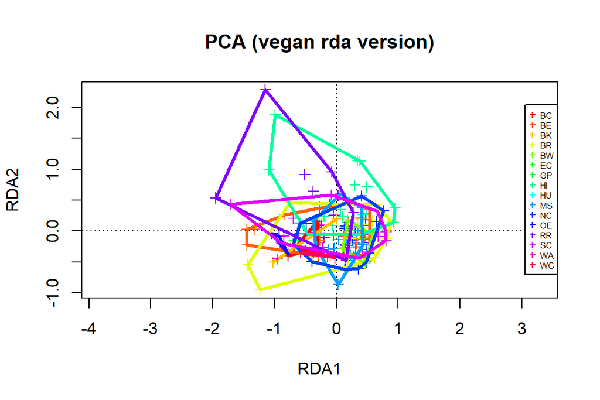

```r
pcapplot<-ordiplot(p_step,scaling=3,type="n")
points(pcapplot, "sites",pch=3, col=colpal_reserv[reserv])

ordihull(pcapplot,groups = reserv, col=colpal_reserv, lwd=3)
title("PCA (vegan rda version)")
legend(x="right", legend=levels(reserv), col=colpal_reserv,pch = 3,cex=0.5)
```

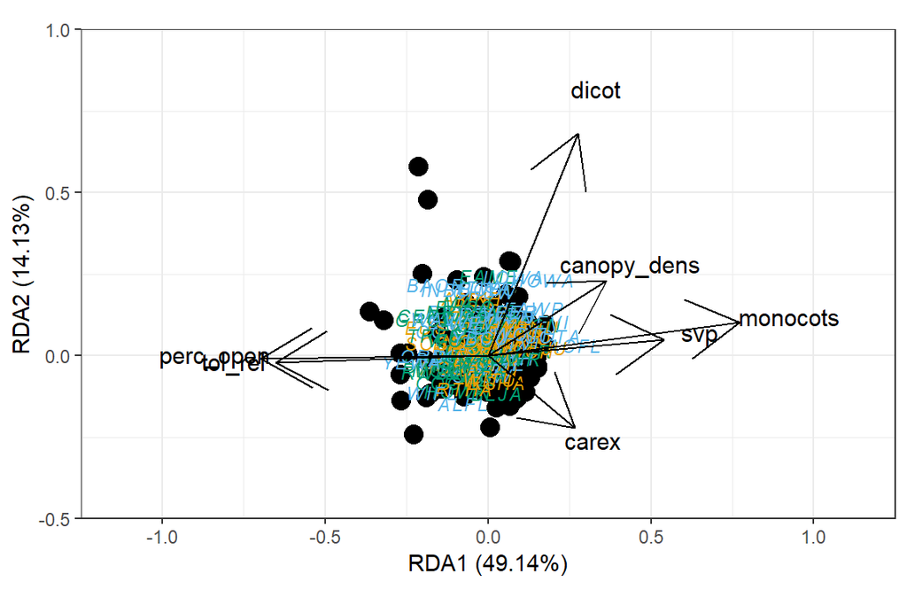

```r
ggord(p_step,  xlim=c(-1.25,1.25),ylim = c(-0.5, 1),txt=4,arrow=TRUE,ptslab=TRUE,addsize=3, size =4,addcol = color_resid)
```

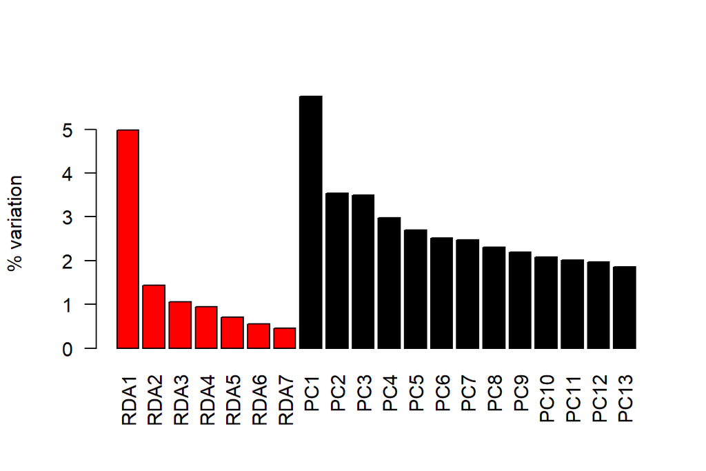

```r
constrained_eig <- p_step$CCA$eig/p_step$tot.chi*100
unconstrained_eig <- p_step$CA$eig/p_step$tot.chi*100
expl_var <- c(constrained_eig, unconstrained_eig)
barplot (expl_var[1:20], col = c(rep ('red', length (constrained_eig)), rep ('black', length (unconstrained_eig))),
         las = 2, ylab = '% variation')
```

We can also explore just the landscape covariate associations:

```r
landcomm_drop$developed.x<-landcomm$developed.x
landcomm_drop<-landcomm_drop[,-5]

p_land<-rda(birdcomm_bin~.,landcomm_drop,scale=T)
fit<-envfit(p_land,landcomm_drop,scale=T)

intersetcor(p_land)
```

```
##                      RDA1        RDA2       RDA3        RDA4        RDA5
## aspect        -0.03873942 -0.12168594  0.1235173  0.44004866 -0.35858504
## twi            0.30152719  0.43569091 -0.2997017  0.21228122  0.01890533
## closest.trail -0.05214285 -0.07162570  0.1401400  0.37529199  0.42536659
## ldi_3k         0.51159907  0.02335322  0.4066976 -0.06706084 -0.03309554
## developed.x   -0.52322757  0.38695462  0.1748675 -0.02844276 -0.02925307
```

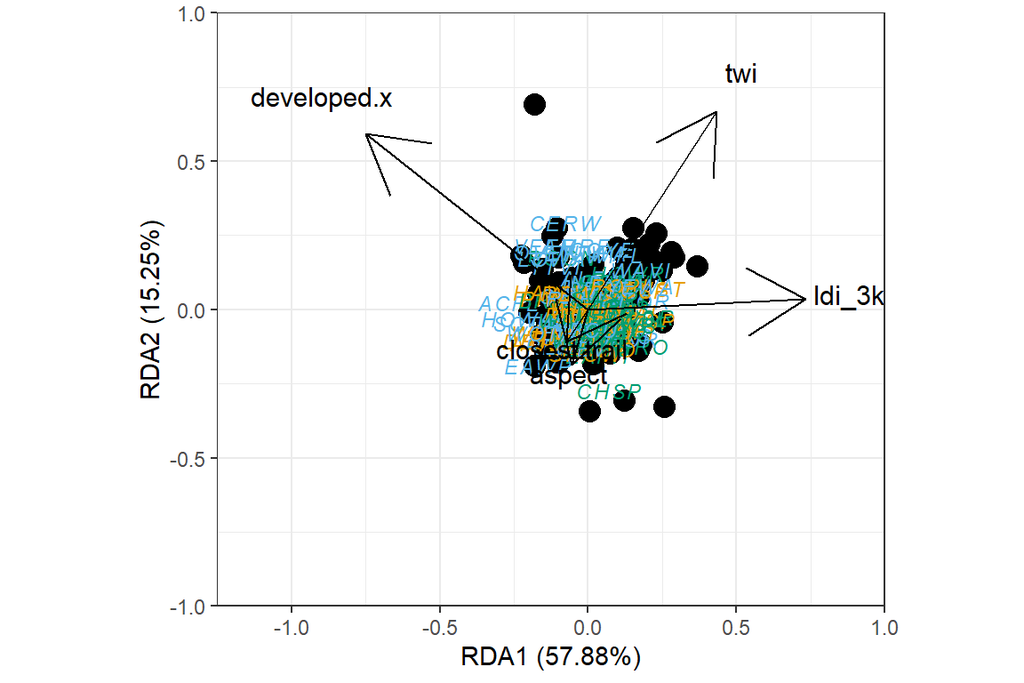

```r
ggord(p_land,  xlim=c(-1.25,1),ylim = c(-1, 1),txt=4,arrow=TRUE,ptslab=TRUE,addsize=3, size =4,addcol = color_resid)
```

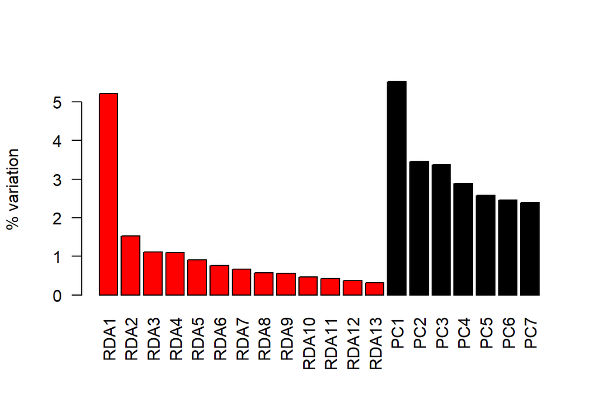

```r
constrained_eig <- p$CCA$eig/p$tot.chi*100
unconstrained_eig <- p$CA$eig/p$tot.chi*100
expl_var <- c(constrained_eig, unconstrained_eig)
barplot (expl_var[1:20], col = c(rep ('red', length (constrained_eig)), rep ('black', length (unconstrained_eig))),
         las = 2, ylab = '% variation')
```

```r
p_land_0<-rda(birdcomm_bin~1,landcomm_drop,scale=T)
p_land_1<-rda(birdcomm_bin~.,landcomm_drop,scale=T)

set.seed(12345)
p_land_step<- ordistep(p_land_0, scope = formula(p_land_1),trace=F)

anova(p_land_step)
```

```
## Permutation test for rda under reduced model
## Permutation: free
## Number of permutations: 999
##
## Model: rda(formula = birdcomm_bin ~ developed.x + ldi_3k + twi, data = landcomm_drop, scale = T)
##           Df Variance      F Pr(>F)
## Model      3    5.894 3.2373  0.001 ***
## Residual 160   97.106
## ---
## Signif. codes:  0 '***' 0.001 '**' 0.01 '*' 0.05 '.' 0.1 ' ' 1
```

```r
anova(p_land_step,by="term")
```

```
## Permutation test for rda under reduced model
## Terms added sequentially (first to last)
## Permutation: free
## Number of permutations: 999
##
## Model: rda(formula = birdcomm_bin ~ developed.x + ldi_3k + twi, data = landcomm_drop, scale = T)
##              Df Variance      F Pr(>F)
## developed.x   1    2.735 4.5071  0.001 ***
## ldi_3k        1    1.706 2.8116  0.001 ***
## twi           1    1.452 2.3932  0.001 ***
## Residual    160   97.106
## ---
## Signif. codes:  0 '***' 0.001 '**' 0.01 '*' 0.05 '.' 0.1 ' ' 1
```

```r
anova(p_land_step,by="axis")
```

```
## Permutation test for rda under reduced model
## Forward tests for axes
## Permutation: free
## Number of permutations: 999
##
## Model: rda(formula = birdcomm_bin ~ developed.x + ldi_3k + twi, data = landcomm_drop, scale = T)
##           Df Variance      F Pr(>F)
## RDA1       1    4.027 6.6349  0.001 ***
## RDA2       1    1.052 1.7335  0.012 *
## RDA3       1    0.815 1.3436  0.027 *
## Residual 160   97.106
## ---
## Signif. codes:  0 '***' 0.001 '**' 0.01 '*' 0.05 '.' 0.1 ' ' 1
```

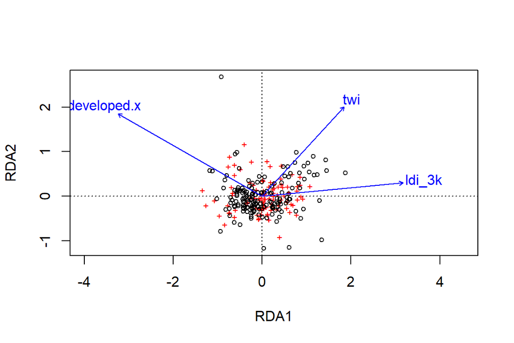

```r
ordiplot(p_land_step,scaling=3)
```

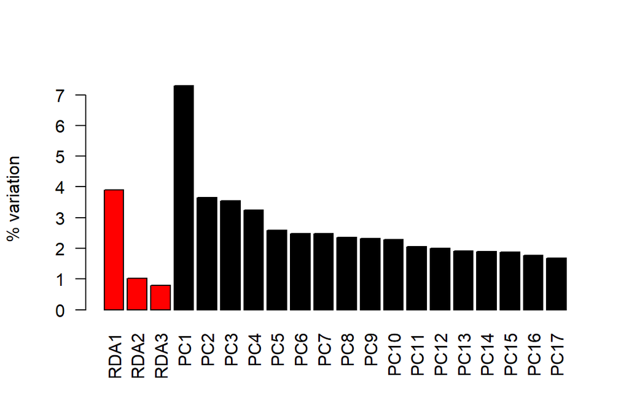

```r
constrained_eig <- p_land_step$CCA$eig/p_land_step$tot.chi*100
unconstrained_eig <- p_land_step$CA$eig/p_land_step$tot.chi*100
expl_var <- c(constrained_eig, unconstrained_eig)
barplot (expl_var[1:20], col = c(rep ('red', length (constrained_eig)), rep ('black', length (unconstrained_eig))),
         las = 2, ylab = '% variation')
```

And now for the vegetation and land cover dataset:

```r
landvegcomm_drop<-cbind(vegecomm_drop,landcomm_drop)

landvegcomm_drop_cor<-cor(landvegcomm_drop)

set.seed(12345)
corvar_landveg<-findCorrelation(landvegcomm_drop_cor,cutoff=0.6)

BBSMigrants<-read.csv("G:/NaturalResources/Byer/datasets/BBS/BBS Migants.csv",header=T)

BBSMigrants_sub<-BBSMigrants[BBSMigrants$SpeciesCode %in% colnames(birdcomm_bin),]

birdcomm_bin_t<-t(birdcomm_bin)

BBSMigrants_sub_reorder<-BBSMigrants_sub[match(rownames(birdcomm_bin_t), BBSMigrants_sub$SpeciesCode),]
color_resid<-BBSMigrants_sub_reorder$Residency

color_resid[color_resid %in% "NE"]<-"#56B4E9"

color_resid[color_resid %in% "M"]<-"#009E73"

color_resid[color_resid %in% "R"]<-"#E69F00"

p_landveg<-rda(birdcomm_bin~.,landvegcomm_drop,scale=T)
fit_landveg<-envfit(p_landveg,landvegcomm_drop,scale=T)

intersetcor(p_landveg)
```

```
##                      RDA1         RDA2         RDA3         RDA4        RDA5         RDA6        RDA7         RDA8         RDA9         RDA10        RDA11        RDA12       RDA13        RDA14       RDA15        RDA16       RDA17       RDA18
## carex         -0.20657719  0.011215855  0.305022105  0.056559100 -0.18420624 -0.279876130  0.04327091 -0.077195829 -0.086471231  0.1335611148 -0.130068905  0.068730876 -0.27559868  0.196305885  0.15862929  0.011073505  0.03315151  0.03507795
## dicot         -0.21605430 -0.462126114 -0.088612898  0.081736363 -0.12793776 -0.245607558 -0.16589507 -0.018622723  0.002232948  0.0445497794 -0.067418762  0.072060477 -0.27524063  0.026994399  0.06893567 -0.098425464 -0.01942504  0.03589463
## shrub         -0.07603861  0.071308054 -0.083505204 -0.049851964  0.10230347  0.314880053 -0.31359276 -0.017001242 -0.118518180  0.3248062912  0.012605574  0.004453416 -0.19642124 -0.020259098  0.04663690  0.019030758 -0.15719707  0.05770396
## hydro         -0.18753009 -0.024134332 -0.001300804 -0.044416620 -0.16141572  0.021350450 -0.11967763  0.009729432  0.267336464  0.0466730445  0.085125542 -0.049059109 -0.01093952  0.202332728 -0.24708795 -0.053801530 -0.29534090  0.04842738
## svp           -0.40226465 -0.086925039  0.130171745  0.006510413  0.18511948 -0.230310530 -0.20886937  0.050014271  0.254960360  0.0388968671  0.010842903 -0.024202995 -0.20034058 -0.006053128 -0.04999395 -0.108493698  0.15879182  0.07364990
## sens_rel      -0.31061166 -0.006975111 -0.039227206 -0.169858273  0.16373963  0.056475799  0.10855406 -0.259294772 -0.059759753 -0.0880652082 -0.053504550  0.216948462 -0.12230700 -0.076652596 -0.08445392 -0.272615637  0.03950200 -0.10907825
## tol_rel        0.46975092 -0.096566500  0.172335970  0.084504992 -0.07602118 -0.235445915 -0.04473005  0.120598704 -0.292168638 -0.0194522637  0.269714311  0.007565310 -0.09721526 -0.041975951 -0.04608403  0.038898115 -0.01334318  0.04373511
## small_tree    -0.05720045 -0.014661363 -0.007035135 -0.022592429 -0.24944807  0.150097685  0.35793180  0.355649728 -0.036901000  0.1028053143  0.068808106 -0.063571725 -0.08955172  0.054943166 -0.13768664 -0.129205919  0.13177939 -0.07807106
## subcanopy_dom -0.08460497 -0.007841935  0.056233276 -0.249852326 -0.14675333  0.155809171 -0.17088309  0.034692308 -0.096597391 -0.2536710621 -0.163128977  0.143948647 -0.18335711  0.070011442 -0.02748936 -0.031293323  0.07513613  0.22741530
## canopy_dens   -0.24878730  0.020053919 -0.309423083 -0.107104360  0.17694385 -0.317687081  0.05828534 -0.011322373 -0.273641805 -0.0677617238 -0.003288877 -0.030501595  0.04556090  0.174429764 -0.02270007  0.112533134 -0.04566127  0.14396129
## canopy_dom    -0.05518186  0.128793432 -0.188801180  0.141557577 -0.03867735  0.006313130 -0.09032072  0.082923146  0.076366919  0.0961945513  0.006795914  0.380886643  0.18146094  0.148138915 -0.24545975 -0.004194690  0.08716355 -0.08285824
## monocots      -0.56525052 -0.053243543 -0.031477156  0.026163232  0.04636413 -0.092631512  0.04340551  0.216668532  0.045051692 -0.0091886631 -0.021012054  0.189325036 -0.08744223 -0.091455044  0.23768256 -0.046514059 -0.12238556 -0.03550781
## perc_open      0.48920875 -0.230322384  0.351049442 -0.161765775  0.19553853 -0.041279637 -0.04762725  0.097741585  0.015790096  0.0009764813  0.032685517  0.047713584 -0.15653133  0.046623545  0.01967973  0.015298197 -0.09412323 -0.06381852
## aspect        -0.02911627 -0.057036087 -0.076162868 -0.133551677 -0.04857421  0.157972899  0.09622809 -0.134841882  0.063158740  0.0712347944  0.373740096  0.143224385  0.11423820  0.175973932  0.29344131 -0.047513362  0.06521987  0.06842626
## twi            0.31342993 -0.050565679  0.232237893  0.274558238 -0.01076886  0.001598647  0.21270200 -0.002260119  0.045406936  0.1081273211 -0.083119875 -0.044475451  0.16276766 -0.030812075  0.04055693 -0.120196082 -0.13028626  0.22428999
## closest.trail -0.05468031 -0.011772684 -0.081666251 -0.064520676  0.02102996 -0.021351276  0.27299073 -0.097520003  0.258456124  0.1733674634  0.071287637  0.151089610 -0.15644428 -0.184073191 -0.09583236  0.253704350  0.01082301  0.12173239
## ldi_3k         0.42308787  0.304880904 -0.369823345  0.120205256  0.04205609  0.140914657  0.03982538 -0.006193730  0.124877864 -0.1386917403 -0.031767872 -0.007739960 -0.14541922  0.146225110  0.04565981  0.009155146  0.01929144 -0.02033885
## developed.x   -0.45164092 -0.283039131  0.165233003  0.283037067  0.20162642  0.220500347  0.10553735 -0.002772269 -0.028512843 -0.0818792026 -0.014335262  0.013931341 -0.02638330  0.113457821 -0.05254973  0.067021181  0.07231622 -0.04765064
```

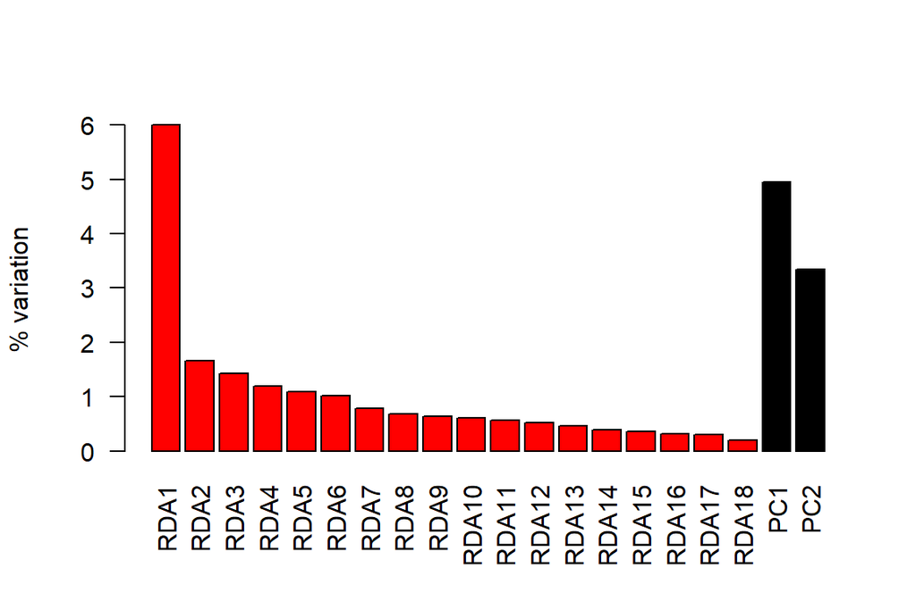

```r
constrained_eig <- p_landveg$CCA$eig/p_landveg$tot.chi*100
unconstrained_eig <- p_landveg$CA$eig/p_landveg$tot.chi*100
expl_var <- c(constrained_eig, unconstrained_eig)
barplot (expl_var[1:20], col = c(rep ('red', length (constrained_eig)), rep ('black', length (unconstrained_eig))),
         las = 2, ylab = '% variation')
```

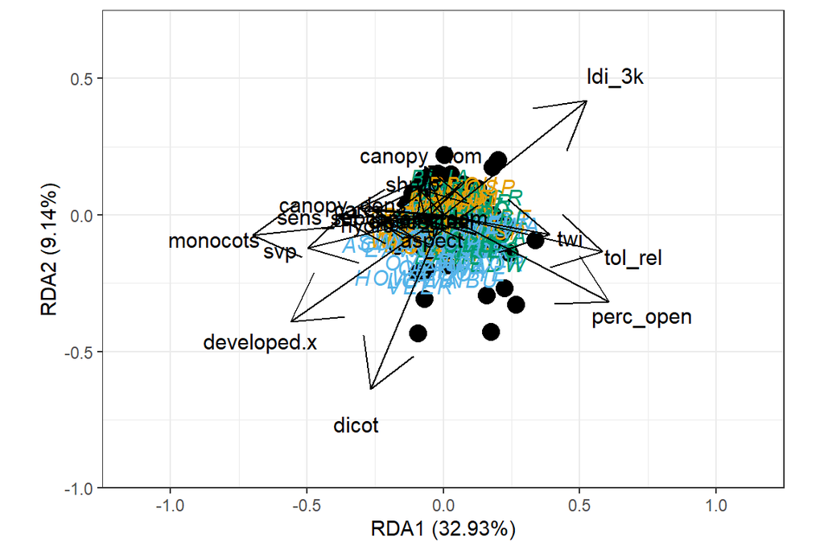

```r
ggord(p_landveg,  xlim=c(-1.25,1.25),ylim = c(-1, 0.75),txt=4,arrow=TRUE,ptslab=TRUE,addsize=4, size =4,addcol = color_resid)
```

```r
intersetcor(p_landveg)
```

```
##                      RDA1         RDA2         RDA3         RDA4        RDA5         RDA6        RDA7         RDA8         RDA9         RDA10        RDA11        RDA12       RDA13        RDA14       RDA15        RDA16       RDA17       RDA18
## carex         -0.20657719  0.011215855  0.305022105  0.056559100 -0.18420624 -0.279876130  0.04327091 -0.077195829 -0.086471231  0.1335611148 -0.130068905  0.068730876 -0.27559868  0.196305885  0.15862929  0.011073505  0.03315151  0.03507795
## dicot         -0.21605430 -0.462126114 -0.088612898  0.081736363 -0.12793776 -0.245607558 -0.16589507 -0.018622723  0.002232948  0.0445497794 -0.067418762  0.072060477 -0.27524063  0.026994399  0.06893567 -0.098425464 -0.01942504  0.03589463
## shrub         -0.07603861  0.071308054 -0.083505204 -0.049851964  0.10230347  0.314880053 -0.31359276 -0.017001242 -0.118518180  0.3248062912  0.012605574  0.004453416 -0.19642124 -0.020259098  0.04663690  0.019030758 -0.15719707  0.05770396
## hydro         -0.18753009 -0.024134332 -0.001300804 -0.044416620 -0.16141572  0.021350450 -0.11967763  0.009729432  0.267336464  0.0466730445  0.085125542 -0.049059109 -0.01093952  0.202332728 -0.24708795 -0.053801530 -0.29534090  0.04842738
## svp           -0.40226465 -0.086925039  0.130171745  0.006510413  0.18511948 -0.230310530 -0.20886937  0.050014271  0.254960360  0.0388968671  0.010842903 -0.024202995 -0.20034058 -0.006053128 -0.04999395 -0.108493698  0.15879182  0.07364990
## sens_rel      -0.31061166 -0.006975111 -0.039227206 -0.169858273  0.16373963  0.056475799  0.10855406 -0.259294772 -0.059759753 -0.0880652082 -0.053504550  0.216948462 -0.12230700 -0.076652596 -0.08445392 -0.272615637  0.03950200 -0.10907825
## tol_rel        0.46975092 -0.096566500  0.172335970  0.084504992 -0.07602118 -0.235445915 -0.04473005  0.120598704 -0.292168638 -0.0194522637  0.269714311  0.007565310 -0.09721526 -0.041975951 -0.04608403  0.038898115 -0.01334318  0.04373511
## small_tree    -0.05720045 -0.014661363 -0.007035135 -0.022592429 -0.24944807  0.150097685  0.35793180  0.355649728 -0.036901000  0.1028053143  0.068808106 -0.063571725 -0.08955172  0.054943166 -0.13768664 -0.129205919  0.13177939 -0.07807106
## subcanopy_dom -0.08460497 -0.007841935  0.056233276 -0.249852326 -0.14675333  0.155809171 -0.17088309  0.034692308 -0.096597391 -0.2536710621 -0.163128977  0.143948647 -0.18335711  0.070011442 -0.02748936 -0.031293323  0.07513613  0.22741530
## canopy_dens   -0.24878730  0.020053919 -0.309423083 -0.107104360  0.17694385 -0.317687081  0.05828534 -0.011322373 -0.273641805 -0.0677617238 -0.003288877 -0.030501595  0.04556090  0.174429764 -0.02270007  0.112533134 -0.04566127  0.14396129
## canopy_dom    -0.05518186  0.128793432 -0.188801180  0.141557577 -0.03867735  0.006313130 -0.09032072  0.082923146  0.076366919  0.0961945513  0.006795914  0.380886643  0.18146094  0.148138915 -0.24545975 -0.004194690  0.08716355 -0.08285824
## monocots      -0.56525052 -0.053243543 -0.031477156  0.026163232  0.04636413 -0.092631512  0.04340551  0.216668532  0.045051692 -0.0091886631 -0.021012054  0.189325036 -0.08744223 -0.091455044  0.23768256 -0.046514059 -0.12238556 -0.03550781
## perc_open      0.48920875 -0.230322384  0.351049442 -0.161765775  0.19553853 -0.041279637 -0.04762725  0.097741585  0.015790096  0.0009764813  0.032685517  0.047713584 -0.15653133  0.046623545  0.01967973  0.015298197 -0.09412323 -0.06381852
## aspect        -0.02911627 -0.057036087 -0.076162868 -0.133551677 -0.04857421  0.157972899  0.09622809 -0.134841882  0.063158740  0.0712347944  0.373740096  0.143224385  0.11423820  0.175973932  0.29344131 -0.047513362  0.06521987  0.06842626
## twi            0.31342993 -0.050565679  0.232237893  0.274558238 -0.01076886  0.001598647  0.21270200 -0.002260119  0.045406936  0.1081273211 -0.083119875 -0.044475451  0.16276766 -0.030812075  0.04055693 -0.120196082 -0.13028626  0.22428999
## closest.trail -0.05468031 -0.011772684 -0.081666251 -0.064520676  0.02102996 -0.021351276  0.27299073 -0.097520003  0.258456124  0.1733674634  0.071287637  0.151089610 -0.15644428 -0.184073191 -0.09583236  0.253704350  0.01082301  0.12173239
## ldi_3k         0.42308787  0.304880904 -0.369823345  0.120205256  0.04205609  0.140914657  0.03982538 -0.006193730  0.124877864 -0.1386917403 -0.031767872 -0.007739960 -0.14541922  0.146225110  0.04565981  0.009155146  0.01929144 -0.02033885
## developed.x   -0.45164092 -0.283039131  0.165233003  0.283037067  0.20162642  0.220500347  0.10553735 -0.002772269 -0.028512843 -0.0818792026 -0.014335262  0.013931341 -0.02638330  0.113457821 -0.05254973  0.067021181  0.07231622 -0.04765064
```

```r
p_landveg_0<-rda(birdcomm_bin~1,landvegcomm_drop,scale=T)
p_landveg_1<-rda(birdcomm_bin~.,landvegcomm_drop,scale=T)

set.seed(12345)
p_landveg_step<- ordistep(p_landveg_0, scope = formula(p_landveg_1),trace = F)
p_landveg_step
```

```
## Call: rda(formula = birdcomm_bin ~ monocots + perc_open + ldi_3k + developed.x + dicot + carex + tol_rel + canopy_dens + svp, data = landvegcomm_drop, scale = T)
##
##                Inertia Proportion Rank
## Total         103.0000     1.0000
## Constrained    13.0876     0.1271    9
## Unconstrained  89.9124     0.8729  102
## Inertia is correlations
##
## Eigenvalues for constrained axes:
##  RDA1  RDA2  RDA3  RDA4  RDA5  RDA6  RDA7  RDA8  RDA9
## 5.818 1.602 1.390 1.086 0.944 0.757 0.573 0.488 0.431
##
## Eigenvalues for unconstrained axes:
##   PC1   PC2   PC3   PC4   PC5   PC6   PC7   PC8
## 5.473 3.559 3.435 2.786 2.632 2.556 2.385 2.323
## (Showing 8 of 102 unconstrained eigenvalues)
```

```r
anova(p_landveg_step)
```

```
## Permutation test for rda under reduced model
## Permutation: free
## Number of permutations: 999
##
## Model: rda(formula = birdcomm_bin ~ monocots + perc_open + ldi_3k + developed.x + dicot + carex + tol_rel + canopy_dens + svp, data = landvegcomm_drop, scale = T)
##           Df Variance      F Pr(>F)
## Model      9   13.088 2.4907  0.001 ***
## Residual 154   89.912
## ---
## Signif. codes:  0 '***' 0.001 '**' 0.01 '*' 0.05 '.' 0.1 ' ' 1
```

```r
anova(p_landveg_step,by="term")
```

```
## Permutation test for rda under reduced model
## Terms added sequentially (first to last)
## Permutation: free
## Number of permutations: 999
##
## Model: rda(formula = birdcomm_bin ~ monocots + perc_open + ldi_3k + developed.x + dicot + carex + tol_rel + canopy_dens + svp, data = landvegcomm_drop, scale = T)
##              Df Variance      F Pr(>F)
## monocots      1    3.297 5.6463  0.001 ***
## perc_open     1    2.093 3.5845  0.001 ***
## ldi_3k        1    1.660 2.8438  0.001 ***
## developed.x   1    1.316 2.2548  0.002 **
## dicot         1    1.085 1.8585  0.002 **
## carex         1    0.990 1.6953  0.005 **
## tol_rel       1    0.863 1.4788  0.017 *
## canopy_dens   1    0.927 1.5877  0.025 *
## svp           1    0.856 1.4664  0.025 *
## Residual    154   89.912
## ---
## Signif. codes:  0 '***' 0.001 '**' 0.01 '*' 0.05 '.' 0.1 ' ' 1
```

```r
anova(p_landveg_step,by="axis")
```

```
## Permutation test for rda under reduced model
## Forward tests for axes
## Permutation: free
## Number of permutations: 999
##
## Model: rda(formula = birdcomm_bin ~ monocots + perc_open + ldi_3k + developed.x + dicot + carex + tol_rel + canopy_dens + svp, data = landvegcomm_drop, scale = T)
##           Df Variance      F Pr(>F)
## RDA1       1    5.818 9.9642  0.001 ***
## RDA2       1    1.602 2.7433  0.001 ***
## RDA3       1    1.390 2.3805  0.002 **
## RDA4       1    1.086 1.8594  0.048 *
## RDA5       1    0.944 1.6170  0.131
## RDA6       1    0.757 1.2959  0.541
## RDA7       1    0.573 0.9813  0.968
## RDA8       1    0.488 0.8356  0.992
## RDA9       1    0.431 0.7390  0.956
## Residual 154   89.912
## ---
## Signif. codes:  0 '***' 0.001 '**' 0.01 '*' 0.05 '.' 0.1 ' ' 1
```

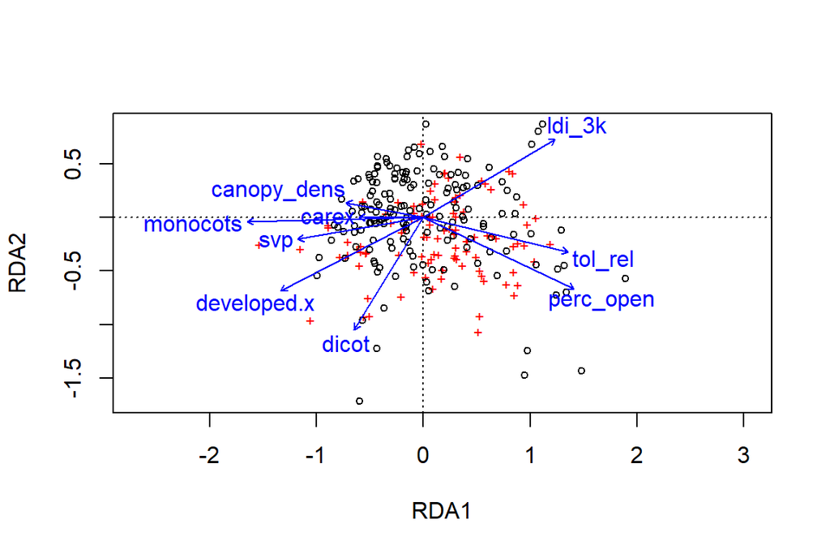

```r
ordiplot(p_landveg_step,scaling=3)
```

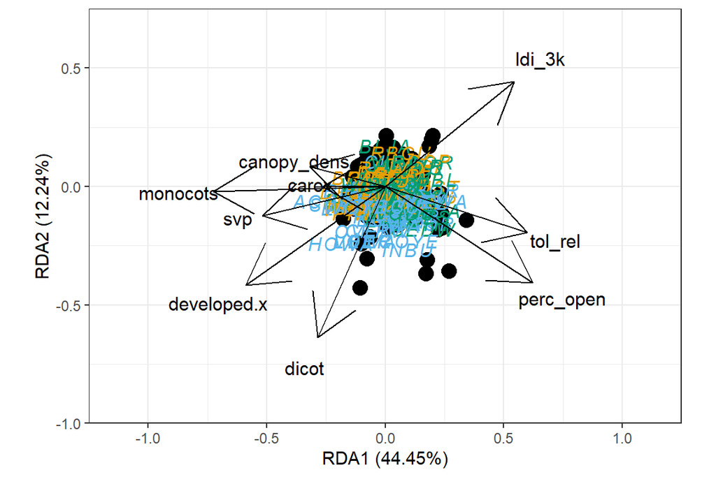

```r
ggord(p_landveg_step,  xlim=c(-1.25,1.25),ylim = c(-1, 0.75),txt=4,arrow=TRUE,ptslab=TRUE,addsize=4, size =4,addcol = color_resid)
```

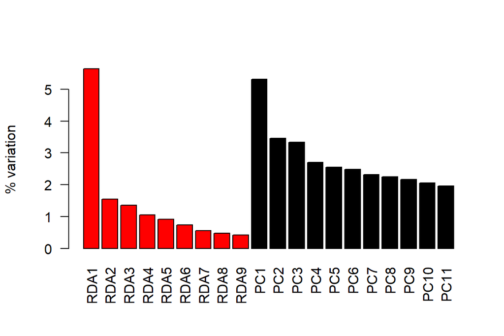

```r
constrained_eig <- p_landveg_step$CCA$eig/p_landveg_step$tot.chi*100
unconstrained_eig <- p_landveg_step$CA$eig/p_landveg_step$tot.chi*100
expl_var <- c(constrained_eig, unconstrained_eig)
barplot (expl_var[1:20], col = c(rep ('red', length (constrained_eig)), rep ('black', length (unconstrained_eig))),
         las = 2, ylab = '% variation')
```

We can also explore bird species most significantly associated with our constrained ordination axes, too. We will focus on the full (land cover and vegetation) ordination.

```r
# envfit() takes the output of metaMDS() and the species matrix you created
fitconcrda <- envfit(p_landveg_step, birdcomm_bin, perm = 999)

# extract p-values for each species
fitconcrda_pvals <- fitconcrda$vectors$pvals %>%
  as.data.frame() %>%
  rownames_to_column("species") %>%
  dplyr::rename("pvals" = ".")

# extract coordinates for species, only keep species with p-val = 0.001
fitconcrda_spp <- fitconcrda %>%
  scores(., display = "vectors") %>%
  as.data.frame() %>%
  rownames_to_column("species") %>%
  full_join(., fitconcrda_pvals, by = "species") %>%
  filter(pvals == 0.001)
```

OK - this is getting towards our main analytical goals! Let’s sort by scores for that first environmental axis and plot these in order:

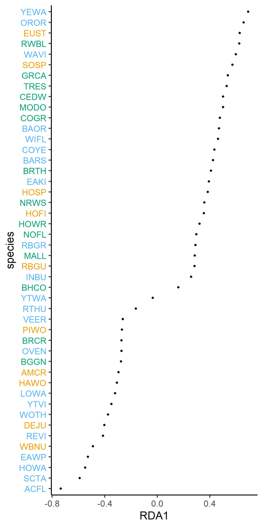

```r
BBSMigrants_sub_sig<-BBSMigrants_sub[BBSMigrants_sub$SpeciesCode %in% fitconcrda_spp$species,]

BBSMigrants_sub_sig_reorder<-BBSMigrants_sub_sig[order(BBSMigrants_sub_sig$SpeciesCode),]

fitconcrda_spp_reorder<-fitconcrda_spp[order(fitconcrda_spp$species),]

fitconcrda_spp_join<-cbind(fitconcrda_spp_reorder,BBSMigrants_sub_sig_reorder)


fitconcrda_spp_order<-fitconcrda_spp_join[order(fitconcrda_spp_join$RDA1),]
fitconcrda_spp_order$species<-factor(fitconcrda_spp_order$species,levels=fitconcrda_spp_order$species)

fitconcrda_spp_order$color_resid[fitconcrda_spp_order$Residency %in% "NE"]<-"#56B4E9"

fitconcrda_spp_order$color_resid[fitconcrda_spp_order$Residency %in% "M"]<-"#009E73"

fitconcrda_spp_order$color_resid[fitconcrda_spp_order$Residency %in% "R"]<-"#E69F00"



color_sub<-fitconcrda_spp_order$color_resid

ggplot(aes(x=RDA1,y=species),data=fitconcrda_spp_order)+geom_point()+theme_classic(base_size=18)+theme(axis.text.y = element_text(colour = color_sub))
```

# multi-species occupancy modelling

After looking at the three, six, and eight sample surveys - virtually *no* sites are surveyed in the seventh and eighth surveys. Thus, using either the three or six sample versions will be best.And the three sample surveys almost always fit better than the six or eight; thus, I will proceed with those.

## MSOM - running different models

### setting some basic parameters for the runs

```r
N <- dim(bbs_occobject$y)[1]
ms.inits <- list(alpha.comm = 0,
                 beta.comm = 0,
                 beta = 0,
                 alpha = 0,
                 tau.sq.beta = 1,
                 tau.sq.alpha = 1,
                 z = apply(bbs_occobject$y, c(1, 2), max, na.rm = TRUE))
ms.priors <- list(beta.comm.normal = list(mean = 0, var = 2.72),
                  alpha.comm.normal = list(mean = 0, var = 2.72),
                  tau.sq.beta.ig = list(a = 0.1, b = 0.1),
                  tau.sq.alpha.ig = list(a = 0.1, b = 0.1))
n.samples<-30000
n.omp.threads<-1
n.report<-6000
n.burn<-10000
n.thin<-50
n.chains<-3
```

### setting up our model statements

```r
bbs_occobject_three$occ.covs[,-(findCorrelation(cor(bbs_occobject_three$occ.covs),cutoff=0.6))]
landcomm_drop
vegecomm_drop

occ_null <- ~1
occ_vibifq <- ~ scale(vibifq)
occ_fqi <- ~ scale(fqi)
occ_tol <- ~ scale(tol_rel)
occ_sens <- ~ scale(sens_rel)
occ_ldi <- ~ scale(ldi)
occ_developed <- ~ scale(developed.x)
occ_senstol <- ~ scale(sens_rel)+scale(tol_rel)
occ_herb <- ~scale(carex)+scale(dicot)+scale(hydro)+scale(svp)+scale(monocots)
occ_structure <- ~ scale(canopy_dens)+scale(canopy_dom)+scale(subcanopy_dom)+scale(small_tree)+scale(perc_open)+scale(shrub)
occ_uncorland <- ~ scale(slope)+scale(aspect)+scale(closest.trail)+scale(ldi)+scale(developed.x)
occ_landrda<-~scale(ldi)+scale(slope)+scale(developed.x)
occ_uncorveg <- ~ scale(carex)+scale(dicot)+scale(shrub)+scale(hydro)+scale(svp)+scale(sens_rel)+scale(tol_rel)+scale(small_tree)+scale(subcanopy_dom)+scale(canopy_dens)+scale(canopy_dom)+scale(monocots)+scale(perc_open)
occ_rdastep<- ~scale(monocots)+scale(perc_open)+scale(dicot)+scale(svp)+scale(carex)+scale(canopy_dens)+scale(tol_rel)
occ_alluncor<-~scale(carex)+scale(dicot)+scale(shrub)+scale(hydro)+scale(svp)+scale(sens_rel)+scale(tol_rel)+scale(developed.x)+scale(ldi)+scale(small_tree)+scale(subcanopy_dom)+scale(canopy_dens)+scale(canopy_dom)+scale(monocots)+scale(perc_open)+scale(slope)+scale(aspect)+scale(closest.trail)
occ_landvegrda<-~scale(monocots)+scale(perc_open)+scale(developed.x)+scale(ldi)+scale(dicot)+scale(carex)+scale(tol_rel)+scale(canopy_dens)+scale(svp)





det_null <- ~1
det_null_randobs<- ~ 1 + I(1|observer)
det_day <- ~ scale(day)
det_day_randobs <- ~ scale(day) + I(1|observer)
det_daytod<- ~ scale(day)+scale(tod)
det_daytod_randobs <- ~ scale(day)+scale(tod)+ I(1|observer)
det_daytodquad <- ~ scale(day)+scale(tod) +I(scale(day)^2)
det_daytodquad_randobs <- ~ scale(day)+scale(tod) +I(scale(day)^2) + I(1|observer)
det_season <- ~ scale(seasons)
det_season_randobs <- ~ scale(seasons) + I(1|observer)
det_dayyearseason <- ~ scale(dayyear) + scale(seasons)
det_dayyearseason_randobs <- ~ scale(dayyear) + scale(seasons) + I(1|observer)
det_dayyeartodseason <- ~ scale(dayyear)+scale(tod)+scale(seasons)
det_dayyeartodseason_randobs <- ~ scale(dayyear)+scale(tod)+scale(seasons) + I(1|observer)
det_dayyeartodseason <- ~ scale(dayyear)+scale(tod)+scale(seasons)
det_dayyeartodseason_randobs <- ~ scale(dayyear)+scale(tod)+scale(seasons)+ I(1|observer)
det_dayyeartodseasonroad <- ~ scale(dayyear)+scale(tod)+scale(seasons)+scale(dist_road)
det_dayyeartodseasonroad_randobs <- ~ scale(dayyear)+scale(tod)+scale(seasons)+scale(dist_road)+I(1|observer)
```

### basic null model

```r
out.ms.null.three <- msPGOcc(occ.formula = occ_null,
                  det.formula = det_null,
                  data = bbs_occobject_three,
                  inits = ms.inits,
                  n.samples = n.samples,
                  priors = ms.priors,
                  n.omp.threads = n.omp.threads,
                  verbose = TRUE,
                  n.report = n.report,
                  n.burn = n.burn,
                  n.thin = n.thin,
                  n.chains = n.chains)
#summary(out.ms.null.three)
#ppc.out.ms.null.three <- ppcOcc(out.ms.null.three, 'freeman-tukey', group = 1)
#summary(ppc.out.ms.null.three)
```

### basic null model - with random effect

```r
out.ms.nullobs.three <- msPGOcc(occ.formula = occ_null,
                  det.formula = det_null_randobs,
                  data = bbs_occobject_three,
                  inits = ms.inits,
                  n.samples = n.samples,
                  priors = ms.priors,
                  n.omp.threads = n.omp.threads,
                  verbose = TRUE,
                  n.report = n.report,
                  n.burn = n.burn,
                  n.thin = n.thin,
                  n.chains = n.chains)
#summary(out.ms.nullobs.three)
#ppc.out.ms.nullobs.three <- ppcOcc(out.ms.nullobs.three, 'freeman-tukey', group = 1)
#summary(ppc.out.ms.nullobs.three)
```

### building up complexity of detection model - just day for now

```r
out.ms.det.day.three <- msPGOcc(occ.formula = occ_null,
                  det.formula = det_day,
                  data = bbs_occobject_three,
                  inits = ms.inits,
                  n.samples = n.samples,
                  priors = ms.priors,
                  n.omp.threads = n.omp.threads,
                  verbose = TRUE,
                  n.report = n.report,
                  n.burn = n.burn,
                  n.thin = n.thin,
                  n.chains = n.chains)


#summary(out.ms.det.day.three)
#ppc.out.ms.det.day.three <- ppcOcc(out.ms.det.day.three, 'freeman-tukey', group = 1)
#summary(ppc.out.ms.det.day.three)
```

### day and random effect

```r
out.ms.detobs.day.three <- msPGOcc(occ.formula = occ_null,
                  det.formula = det_day_randobs,
                  data = bbs_occobject_three,
                  inits = ms.inits,
                  n.samples = n.samples,
                  priors = ms.priors,
                  n.omp.threads = n.omp.threads,
                  verbose = TRUE,
                  n.report = n.report,
                  n.burn = n.burn,
                  n.thin = n.thin,
                  n.chains = n.chains)


#summary(out.ms.detobs.day.three)
#ppc.out.ms.detobs.day.three <- ppcOcc(out.ms.detobs.day.three, 'freeman-tukey', group = 1)
#summary(ppc.out.ms.detobs.day.three)
```

### day and time-of-day

```r
out.ms.det.daytod.three <- msPGOcc(occ.formula = occ_null,
                  det.formula = det_daytod,
                  data = bbs_occobject_three,
                  inits = ms.inits,
                  n.samples = n.samples,
                  priors = ms.priors,
                  n.omp.threads = n.omp.threads,
                  verbose = TRUE,
                  n.report = n.report,
                  n.burn = n.burn,
                  n.thin = n.thin,
                  n.chains = n.chains)
#summary(out.ms.det.daytod.three)
#ppc.out.ms.det.daytod.three <- ppcOcc(out.ms.det.daytod.three, 'freeman-tukey', group = 1)
#summary(ppc.out.ms.det.daytod.three)
```

### day and time-of-day - random observer

```r
out.ms.detobs.daytod.three <- msPGOcc(occ.formula = occ_null,
                  det.formula = det_daytod_randobs,
                  data = bbs_occobject_three,
                  inits = ms.inits,
                  n.samples = n.samples,
                  priors = ms.priors,
                  n.omp.threads = n.omp.threads,
                  verbose = TRUE,
                  n.report = n.report,
                  n.burn = n.burn,
                  n.thin = n.thin,
                  n.chains = n.chains)
#summary(out.ms.detobs.daytod.three)
#ppc.out.ms.detobs.daytod.three <- ppcOcc(out.ms.detobs.daytod.three, 'freeman-tukey', group = 1)
#summary(ppc.out.ms.detobs.daytod.three)
```

### day, tod, quadratic day

```r
out.ms.det.daytodquad.three<- msPGOcc(occ.formula = occ_null,
                  det.formula = det_daytodquad,
                  data = bbs_occobject_three,
                  inits = ms.inits,
                  n.samples = n.samples,
                  priors = ms.priors,
                  n.omp.threads = n.omp.threads,
                  verbose = TRUE,
                  n.report = n.report,
                  n.burn = n.burn,
                  n.thin = n.thin,
                  n.chains = n.chains)
#summary(out.ms.det.daytodquad.three)
#ppc.out.ms.det.daytodquad.three <- ppcOcc(out.ms.det.daytodquad.three, 'freeman-tukey', group = 1)
#summary(ppc.out.ms.det.daytodquad.three)
```

### day, tod, quadratic day - random observer

```r
out.ms.detobs.daytodquad.three<- msPGOcc(occ.formula = occ_null,
                  det.formula = det_daytodquad_randobs,
                  data = bbs_occobject_three,
                  inits = ms.inits,
                  n.samples = n.samples,
                  priors = ms.priors,
                  n.omp.threads = n.omp.threads,
                  verbose = TRUE,
                  n.report = n.report,
                  n.burn = n.burn,
                  n.thin = n.thin,
                  n.chains = n.chains)
#summary(out.ms.detobs.daytodquad.three)
#ppc.out.ms.detobs.daytodquad.three <- ppcOcc(out.ms.detobs.daytodquad.three, 'freeman-tukey', group = 1)
#summary(ppc.out.ms.detobs.daytodquad.three)
```

### season alone

```r
out.ms.det.season.three<- msPGOcc(occ.formula = occ_null,
                  det.formula = det_season,
                  data = bbs_occobject_three,
                  inits = ms.inits,
                  n.samples = n.samples,
                  priors = ms.priors,
                  n.omp.threads = n.omp.threads,
                  verbose = TRUE,
                  n.report = n.report,
                  n.burn = n.burn,
                  n.thin = n.thin,
                  n.chains = n.chains)
#summary(out.ms.det.season.three)
#ppc.out.ms.det.season.three <- ppcOcc(out.ms.det.season.three, 'freeman-tukey', group = 1)
#summary(ppc.out.ms.det.season.three)
```

### season alone - random observer

```r
out.ms.detobs.season.three<- msPGOcc(occ.formula = occ_null,
                  det.formula = det_season_randobs,
                  data = bbs_occobject_three,
                  inits = ms.inits,
                  n.samples = n.samples,
                  priors = ms.priors,
                  n.omp.threads = n.omp.threads,
                  verbose = TRUE,
                  n.report = n.report,
                  n.burn = n.burn,
                  n.thin = n.thin,
                  n.chains = n.chains)
#summary(out.ms.detobs.season.three)
#ppc.out.ms.detobs.season.three <- ppcOcc(out.ms.detobs.season.three, 'freeman-tukey', group = 1)
#summary(ppc.out.ms.detobs.season.three)
```

### day of year and season

```r
out.ms.det.dayyearseason.three<- msPGOcc(occ.formula = occ_null,
                  det.formula = det_dayyearseason,
                  data = bbs_occobject_three,
                  inits = ms.inits,
                  n.samples = n.samples,
                  priors = ms.priors,
                  n.omp.threads = n.omp.threads,
                  verbose = TRUE,
                  n.report = n.report,
                  n.burn = n.burn,
                  n.thin = n.thin,
                  n.chains = n.chains)
#summary(out.ms.det.dayyearseason.three)
#ppc.out.ms.det.dayyearseason.three <- ppcOcc(out.ms.det.dayyearseason.three, 'freeman-tukey', group = 1)
#summary(ppc.out.ms.det.dayyearseason.three)
```

### day of year and season - random observer

```r
out.ms.detobs.dayyearseason.three<- msPGOcc(occ.formula = occ_null,
                  det.formula = det_dayyearseason_randobs,
                  data = bbs_occobject_three,
                  inits = ms.inits,
                  n.samples = n.samples,
                  priors = ms.priors,
                  n.omp.threads = n.omp.threads,
                  verbose = TRUE,
                  n.report = n.report,
                  n.burn = n.burn,
                  n.thin = n.thin,
                  n.chains = n.chains)
#summary(out.ms.detobs.dayyearseason.three)
#ppc.out.ms.detobs.dayyearseason.three <- ppcOcc(out.ms.detobs.dayyearseason.three, 'freeman-tukey', group = 1)
#summary(ppc.out.ms.detobs.dayyearseason.three)
```

### day in year, tod, season

```r
out.ms.det.dayyeartodseason.three<- msPGOcc(occ.formula = occ_null,
                  det.formula = det_dayyeartodseason,
                  data = bbs_occobject_three,
                  inits = ms.inits,
                  n.samples = n.samples,
                  priors = ms.priors,
                  n.omp.threads = n.omp.threads,
                  verbose = TRUE,
                  n.report = n.report,
                  n.burn = n.burn,
                  n.thin = n.thin,
                  n.chains = n.chains)
#summary(out.ms.det.dayyeartodseason.three)
#ppc.out.ms.det.dayyeartodseason.three <- ppcOcc(out.ms.det.dayyeartodseason.three, 'freeman-tukey', group = 1)
#summary(ppc.out.ms.det.dayyeartodseason.three)
```

### day in year, tod, season - random observer

```r
out.ms.detobs.dayyeartodseason.three<- msPGOcc(occ.formula = occ_null,
                  det.formula = det_dayyeartodseason_randobs,
                  data = bbs_occobject_three,
                  inits = ms.inits,
                  n.samples = n.samples,
                  priors = ms.priors,
                  n.omp.threads = n.omp.threads,
                  verbose = TRUE,
                  n.report = n.report,
                  n.burn = n.burn,
                  n.thin = n.thin,
                  n.chains = n.chains)
#summary(out.ms.detobs.dayyeartodseason.three)
#ppc.out.ms.detobs.dayyeartodseason.three <- ppcOcc(out.ms.detobs.dayyeartodseason.three, 'freeman-tukey', group = 1)
#summary(ppc.out.ms.detobs.dayyeartodseason.three)
```

### day in year, tod, season, and roads

```r
out.ms.det.dayyeartodseasonroad.three<- msPGOcc(occ.formula = occ_null,
                  det.formula = det_dayyeartodseasonroad,
                  data = bbs_occobject_three,
                  inits = ms.inits,
                  n.samples = n.samples,
                  priors = ms.priors,
                  n.omp.threads = n.omp.threads,
                  verbose = TRUE,
                  n.report = n.report,
                  n.burn = n.burn,
                  n.thin = n.thin,
                  n.chains = n.chains)
#summary(out.ms.det.dayyeartodseasonroad.three)
#ppc.out.ms.det.dayyeartodseasonroad.three <- ppcOcc(out.ms.det.dayyeartodseasonroad.three, 'freeman-tukey', group = 1)
#summary(ppc.out.ms.det.dayyeartodseasonroad.three)
```

### day in year, tod, season - random observer

```r
out.ms.detobs.dayyeartodseasonroad.three<- msPGOcc(occ.formula = occ_null,
                  det.formula = det_dayyeartodseasonroad_randobs,
                  data = bbs_occobject_three,
                  inits = ms.inits,
                  n.samples = n.samples,
                  priors = ms.priors,
                  n.omp.threads = n.omp.threads,
                  verbose = TRUE,
                  n.report = n.report,
                  n.burn = n.burn,
                  n.thin = n.thin,
                  n.chains = n.chains)
#summary(out.ms.detobs.dayyeartodseasonroad.three)
#ppc.out.ms.detobs.dayyeartodseasonroad.three <- ppcOcc(out.ms.detobs.dayyeartodseasonroad.three, 'freeman-tukey', group = 1)
#summary(ppc.out.ms.detobs.dayyeartodseasonroad.three)
```

### selecting fixed effects detection model

```r
det1<-waicOcc(out.ms.null.three)
det2<-waicOcc(out.ms.det.day.three)
det3<-waicOcc(out.ms.det.daytod.three)
det4<-waicOcc(out.ms.det.daytodquad.three)
det5<-waicOcc(out.ms.det.season.three)
det6<-waicOcc(out.ms.det.dayyearseason.three)
det7<-waicOcc(out.ms.det.dayyeartodseason.three)
det8<-waicOcc(out.ms.det.dayyeartodseasonroad.three)
```

### selecting random effect detection model

```r
detobs1<-waicOcc(out.ms.null.three)
detobs2<-waicOcc(out.ms.detobs.day.three)
detobs3<-waicOcc(out.ms.detobs.daytod.three)
detobs4<-waicOcc(out.ms.detobs.daytodquad.three)
detobs5<-waicOcc(out.ms.detobs.season.three)
detobs6<-waicOcc(out.ms.detobs.dayyearseason.three)
detobs7<-waicOcc(out.ms.detobs.dayyeartodseason.three)
detobs8<-waicOcc(out.ms.detobs.dayyeartodseasonroad.three)
save.image(file="rerunning_occ_models_12272022.RData")
```

The best-supported model is day of year, time of day, season, and distance to road. Thus, we will proceed with that one for now.

Now we will run several different occupancy submodels, once again evaluating fit for progressively more complicated models.

### occupancy model with vibi-fq

```r
out.ms.vibifq <- msPGOcc(occ.formula = occ_vibifq,
                  det.formula = det_dayyeartodseasonroad_randobs,
                  data = bbs_occobject_three,
                  inits = ms.inits,
                  n.samples = n.samples,
                  priors = ms.priors,
                  n.omp.threads = n.omp.threads,
                  verbose = TRUE,
                  n.report = n.report,
                  n.burn = n.burn,
                  n.thin = n.thin,
                  n.chains = n.chains)
summary(out.ms.vibifq)
ppc.out.ms.vibifq <- ppcOcc(out.ms.vibifq, 'freeman-tukey', group = 1)
summary(ppc.out.ms.vibifq)

waicOcc(out.ms.vibifq)
```

### just FQAI

```r
out.ms.fqi <- msPGOcc(occ.formula = occ_fqi,
                  det.formula = det_best,
                  data = bbs_occobject_three,
                  inits = ms.inits,
                  n.samples = n.samples,
                  priors = ms.priors,
                  n.omp.threads = n.omp.threads,
                  verbose = TRUE,
                  n.report = n.report,
                  n.burn = n.burn,
                  n.thin = n.thin,
                  n.chains = n.chains)
summary(out.ms.fqi)
ppc.out.ms.fqi <- ppcOcc(out.ms.fqi, 'freeman-tukey', group = 1)
summary(ppc.out.ms.fqi)

waicOcc(out.ms.fqi)
```

### just tolerance

```r
out.ms.tol <- msPGOcc(occ.formula = occ_tol,
                  det.formula = det_best,
                  data = bbs_occobject_three,
                  inits = ms.inits,
                  n.samples = n.samples,
                  priors = ms.priors,
                  n.omp.threads = n.omp.threads,
                  verbose = TRUE,
                  n.report = n.report,
                  n.burn = n.burn,
                  n.thin = n.thin,
                  n.chains = n.chains)
summary(out.ms.tol)
ppc.out.ms.tol <- ppcOcc(out.ms.tol, 'freeman-tukey', group = 1)
summary(ppc.out.ms.tol)

waicOcc(out.ms.tol)
```

### just sensitivity

```r
out.ms.sens <- msPGOcc(occ.formula = occ_sens,
                  det.formula = det_best,
                  data = bbs_occobject_three,
                  inits = ms.inits,
                  n.samples = n.samples,
                  priors = ms.priors,
                  n.omp.threads = n.omp.threads,
                  verbose = TRUE,
                  n.report = n.report,
                  n.burn = n.burn,
                  n.thin = n.thin,
                  n.chains = n.chains)
summary(out.ms.sens)
ppc.out.ms.sens <- ppcOcc(out.ms.sens, 'freeman-tukey', group = 1)
summary(ppc.out.ms.sens)

waicOcc(out.ms.sens)
```

### just ldi

```r
out.ms.ldi <- msPGOcc(occ.formula = occ_ldi,
                  det.formula = det_best,
                  data = bbs_occobject_three,
                  inits = ms.inits,
                  n.samples = n.samples,
                  priors = ms.priors,
                  n.omp.threads = n.omp.threads,
                  verbose = TRUE,
                  n.report = n.report,
                  n.burn = n.burn,
                  n.thin = n.thin,
                  n.chains = n.chains)
summary(out.ms.ldi)
ppc.out.ms.ldi <- ppcOcc(out.ms.ldi, 'freeman-tukey', group = 1)
summary(ppc.out.ms.ldi)

waicOcc(out.ms.ldi)
```

### just developed

```r
out.ms.developed <- msPGOcc(occ.formula = occ_developed,
                  det.formula = det_best,
                  data = bbs_occobject_three,
                  inits = ms.inits,
                  n.samples = n.samples,
                  priors = ms.priors,
                  n.omp.threads = n.omp.threads,
                  verbose = TRUE,
                  n.report = n.report,
                  n.burn = n.burn,
                  n.thin = n.thin,
                  n.chains = n.chains)
summary(out.ms.developed)
ppc.out.ms.developed <- ppcOcc(out.ms.developed, 'freeman-tukey', group = 1)
summary(ppc.out.ms.developed)

waicOcc(out.ms.developed)
```

### just sensitive and tolerance

```r
out.ms.senstol <- msPGOcc(occ.formula = occ_senstol,
                  det.formula = det_best,
                  data = bbs_occobject_three,
                  inits = ms.inits,
                  n.samples = n.samples,
                  priors = ms.priors,
                  n.omp.threads = n.omp.threads,
                  verbose = TRUE,
                  n.report = n.report,
                  n.burn = n.burn,
                  n.thin = n.thin,
                  n.chains = n.chains)
summary(out.ms.senstol)
ppc.out.ms.senstol <- ppcOcc(out.ms.senstol, 'freeman-tukey', group = 1)
summary(ppc.out.ms.senstol)

waicOcc(out.ms.senstol)
```

### herbaceous

```r
out.ms.herb <- msPGOcc(occ.formula = occ_herb,
                  det.formula = det_best,
                  data = bbs_occobject_three,
                  inits = ms.inits,
                  n.samples = n.samples,
                  priors = ms.priors,
                  n.omp.threads = n.omp.threads,
                  verbose = TRUE,
                  n.report = n.report,
                  n.burn = n.burn,
                  n.thin = n.thin,
                  n.chains = n.chains)


summary(out.ms.herb)
ppc.out.ms.herb <- ppcOcc(out.ms.herb, 'freeman-tukey', group = 1)
summary(ppc.out.ms.herb)

waicOcc(out.ms.herb)
```

### structure

```r
out.ms.structure <- msPGOcc(occ.formula = occ_structure,
                  det.formula = det_best,
                  data = bbs_occobject_three,
                  inits = ms.inits,
                  n.samples = n.samples,
                  priors = ms.priors,
                  n.omp.threads = n.omp.threads,
                  verbose = TRUE,
                  n.report = n.report,
                  n.burn = n.burn,
                  n.thin = n.thin,
                  n.chains = n.chains)


summary(out.ms.structure)
ppc.out.ms.structure <- ppcOcc(out.ms.structure, 'freeman-tukey', group = 1)
summary(ppc.out.ms.structure)

waicOcc(out.ms.structure)
```

### uncorrelated landscape variables

```r
out.ms.uncorland <- msPGOcc(occ.formula = occ_uncorland,
                  det.formula = det_best,
                  data = bbs_occobject_three,
                  inits = ms.inits,
                  n.samples = n.samples,
                  priors = ms.priors,
                  n.omp.threads = n.omp.threads,
                  verbose = TRUE,
                  n.report = n.report,
                  n.burn = n.burn,
                  n.thin = n.thin,
                  n.chains = n.chains)


summary(out.ms.uncorland)
ppc.out.ms.uncorland <- ppcOcc(out.ms.uncorland, 'freeman-tukey', group = 1)
summary(ppc.out.ms.uncorland)

waicOcc(out.ms.uncorland)
```

### landscape variable - RDA supported

```r
out.ms.landrda<- msPGOcc(occ.formula = occ_landrda,
                  det.formula = det_best,
                  data = bbs_occobject_three,
                  inits = ms.inits,
                  n.samples = n.samples,
                  priors = ms.priors,
                  n.omp.threads = n.omp.threads,
                  verbose = TRUE,
                  n.report = n.report,
                  n.burn = n.burn,
                  n.thin = n.thin,
                  n.chains = n.chains)


summary(out.ms.landrda)
ppc.out.ms.landrda <- ppcOcc(out.ms.landrda, 'freeman-tukey', group = 1)
summary(ppc.out.ms.landrda)

waicOcc(out.ms.landrda)
```

### Uncorrelated vegetation variables - not positive definite

```r
out.ms.uncorveg<- msPGOcc(occ.formula = occ_uncorveg,
                  det.formula = det_best,
                  data = bbs_occobject_three,
                  inits = ms.inits,
                  n.samples = n.samples,
                  priors = ms.priors,
                  n.omp.threads = n.omp.threads,
                  verbose = TRUE,
                  n.report = n.report,
                  n.burn = n.burn,
                  n.thin = n.thin,
                  n.chains = n.chains)


summary(out.ms.uncorveg)
ppc.out.ms.uncorveg <- ppcOcc(out.ms.uncorveg, 'freeman-tukey', group = 1)
summary(ppc.out.ms.uncorveg)

waicOcc(out.ms.uncorveg)
```

### RDA supported vegetation covariates

```r
out.ms.rdastep<- msPGOcc(occ.formula = occ_rdastep,
                  det.formula = det_best,
                  data = bbs_occobject_three,
                  inits = ms.inits,
                  n.samples = n.samples,
                  priors = ms.priors,
                  n.omp.threads = n.omp.threads,
                  verbose = TRUE,
                  n.report = n.report,
                  n.burn = n.burn,
                  n.thin = n.thin,
                  n.chains = n.chains)


summary(out.ms.rdastep)
ppc.out.ms.rdastep <- ppcOcc(out.ms.rdastep, 'freeman-tukey', group = 1)
summary(ppc.out.ms.rdastep)

waicOcc(out.ms.rdastep)
```

### all RDA-supported covariates

```r
out.ms.landvegrda<- msPGOcc(occ.formula = occ_landvegrda,
                  det.formula = det_best,
                  data = bbs_occobject_three,
                  inits = ms.inits,
                  n.samples = n.samples,
                  priors = ms.priors,
                  n.omp.threads = n.omp.threads,
                  verbose = TRUE,
                  n.report = n.report,
                  n.burn = n.burn,
                  n.thin = n.thin,
                  n.chains = n.chains)


summary(out.ms.landvegrda)
ppc.out.ms.landvegrda <- ppcOcc(out.ms.landvegrda, 'freeman-tukey', group = 1)
summary(ppc.out.ms.landvegrda)

waicOcc(out.ms.landvegrda)
```

### writing out this model

```r
write_rds(out.ms.landvegrda,"G:/NaturalResources/Byer/datasets/BBS/out.ms.fulllandveg.rds")
```

### model selection

we can also print out a table of Widely Applicable Information Criterion (wAIC) values. The lower this is, the better the model fit.

```r
AICc_table<-tibble(.rows = 9)

AICc_table$model<-c("Null", "p ~ day + tod + season + dist_roads, psi ~ tol_rel + svp + dicot + cyper + small_tree + shrub + hydro + subcanopy + canopy", "p ~ day + tod + season + dist_roads, psi ~ tol_rel + svp + dicot + cyper + ldi + developed","p ~ day + tod + season + dist_roads, psi ~ developed + activityarea + sanctionedtrail + bootlegtrail + streamedge + ldi","p ~ day + tod + season + dist_roads,psi~tol_rel + svp + dicot + cyper + small_tree","p ~ day + tod + season + dist_roads,psi~canopy + subcanopy + small_tree","p ~ day + tod + season + dist_roads,psi~tol_rel","p ~ day + tod + season + dist_roads,psi~vibi","p ~ day + tod + season + dist_roads,psi~vibi_notrees")

AICc_table$wAIC<-c(waicOcc(out.ms.nullobs)[[3]],waicOcc(out.ms.allveg)[[3]],waicOcc(out.ms.fulllandveg)[[3]],waicOcc(out.ms.land)[[3]],waicOcc(out.ms.rdaveg)[[3]],
                   waicOcc(out.ms.structure)[[3]],waicOcc(out.ms.tolerance)[[3]],waicOcc(out.ms.vibifq)[[3]],waicOcc(out.ms.vibifqnotrees)[[3]])
```

|  | model | wAIC |
| --- | --- | --- |
| 3 | p ~ day + tod + season + dist_roads, psi ~ tol_rel + svp + dicot + cyper + ldi + developed | 35681.75 |
| 2 | p ~ day + tod + season + dist_roads, psi ~ tol_rel + svp + dicot + cyper + small_tree + shrub + hydro + subcanopy + canopy | 35854.36 |
| 5 | p ~ day + tod + season + dist_roads,psi~tol_rel + svp + dicot + cyper + small_tree | 35874.89 |
| 8 | p ~ day + tod + season + dist_roads,psi~vibi | 35882.12 |
| 7 | p ~ day + tod + season + dist_roads,psi~tol_rel | 36040.55 |
| 9 | p ~ day + tod + season + dist_roads,psi~vibi_notrees | 36066.59 |
| 4 | p ~ day + tod + season + dist_roads, psi ~ developed + activityarea + sanctionedtrail + bootlegtrail + streamedge + ldi | 36172.77 |
| 6 | p ~ day + tod + season + dist_roads,psi~canopy + subcanopy + small_tree | 36402.48 |
| 1 | Null | 36879.23 |

So, the top model is the model with a mix of land cover and vegetation covariates!

Now, we plot based on this top model - after running it for a bit longer.

```r
out.ms.landvegrda_2 <- msPGOcc(occ.formula = occ_landvegrda,
                  det.formula = det_best,
                  data = bbs_occobject_three,
                  inits = ms.inits,
                  n.samples = 200000,
                  priors = ms.priors,
                  n.omp.threads = 4,
                  verbose = TRUE,
                  n.report = 10000,
                  n.burn = 10000,
                  n.thin = 100,
                  n.chains = n.chains)


summary(out.ms.landvegrda_2)
ppc.out.ms.landvegrda_2 <- ppcOcc(out.ms.landvegrda_2, 'freeman-tukey', group = 1)
summary(ppc.out.ms.landvegrda_2)

waicOcc(out.ms.landvegrda_2)

write_rds(out.ms.landvegrda_2,"G:/NaturalResources/Byer/datasets/BBS/out.ms.landvegrda_2.rds")

out.ms.landvegrda_2<-read_rds("G:/NaturalResources/Byer/datasets/BBS/out.ms.landvegrda_2.rds")
```

### plot single covariate effects

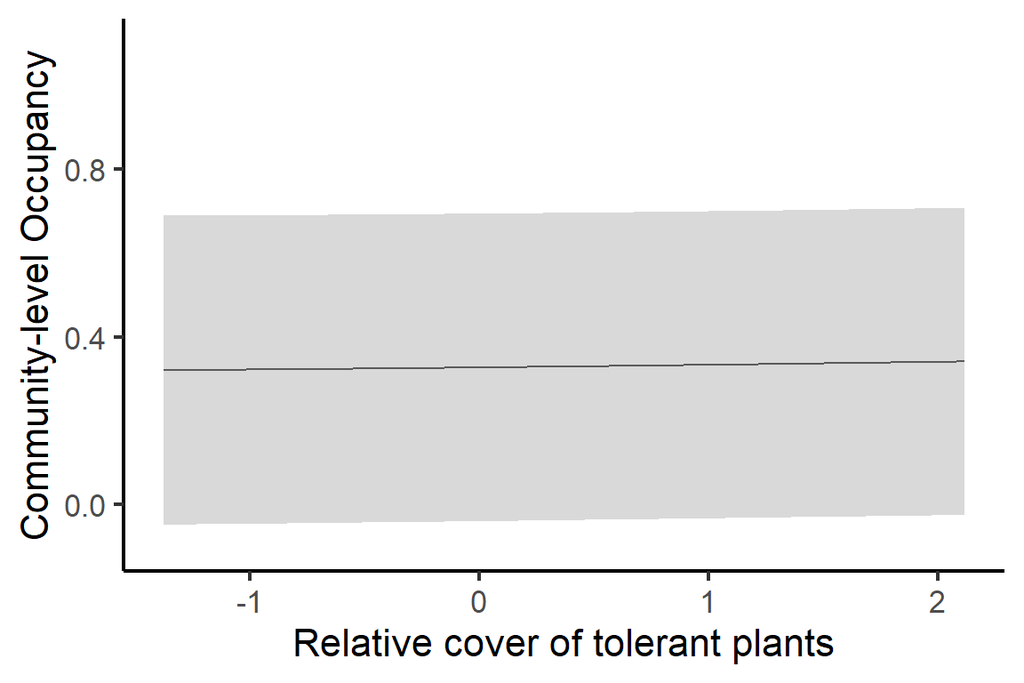

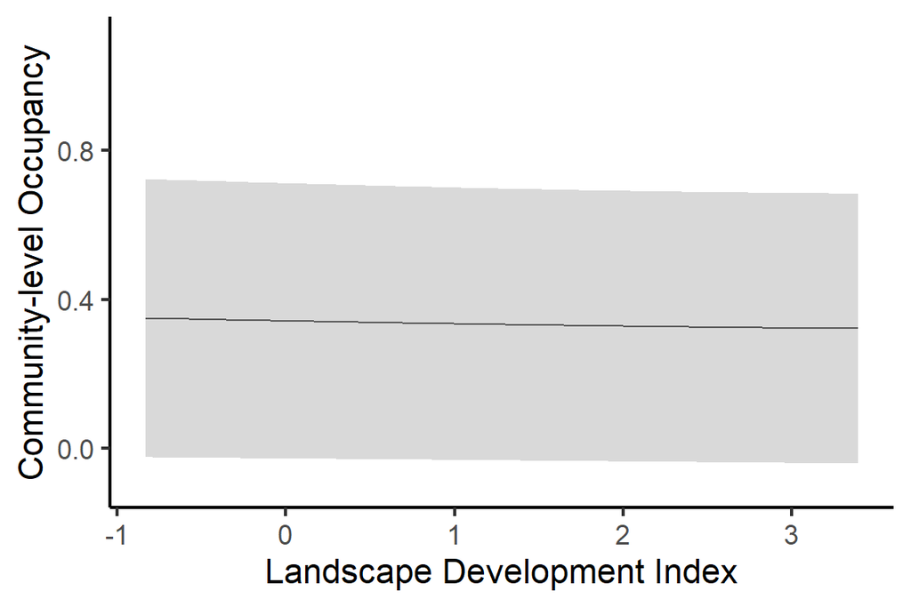

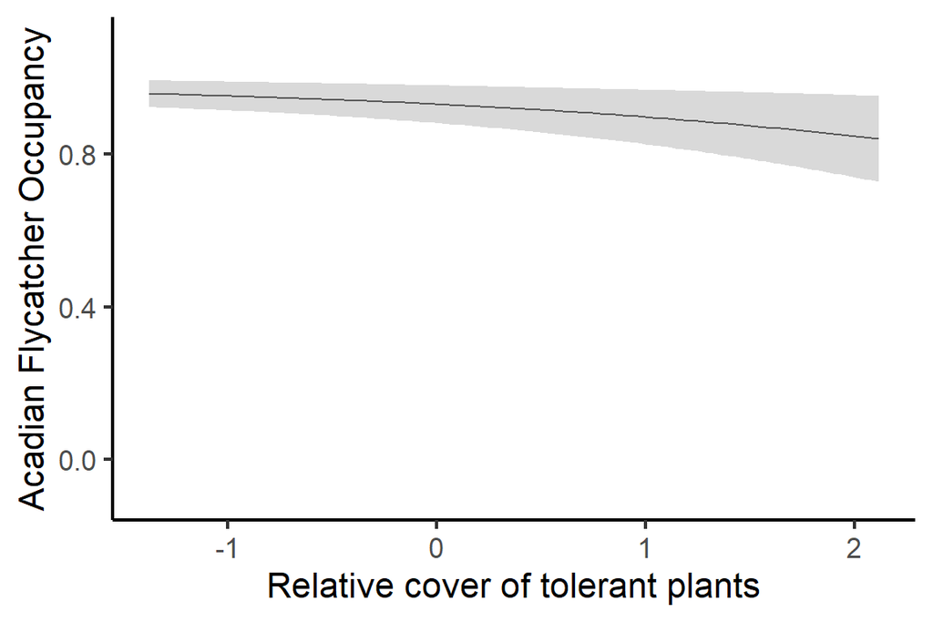

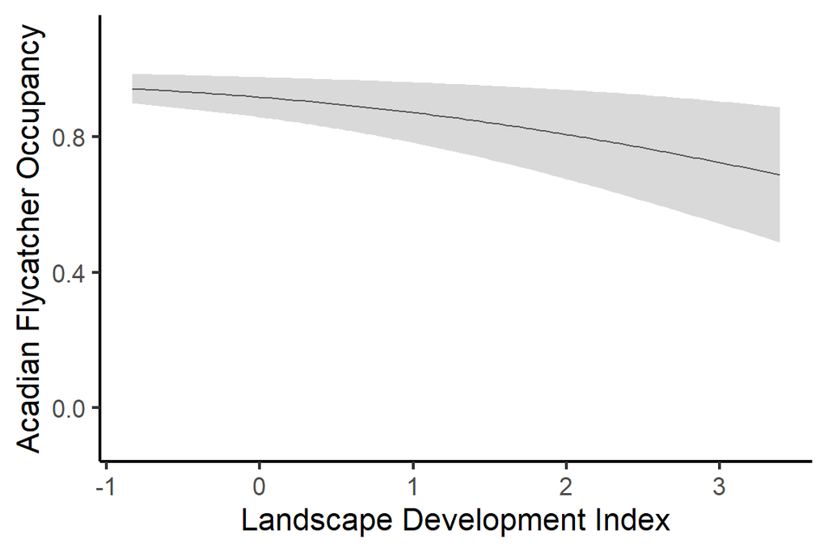

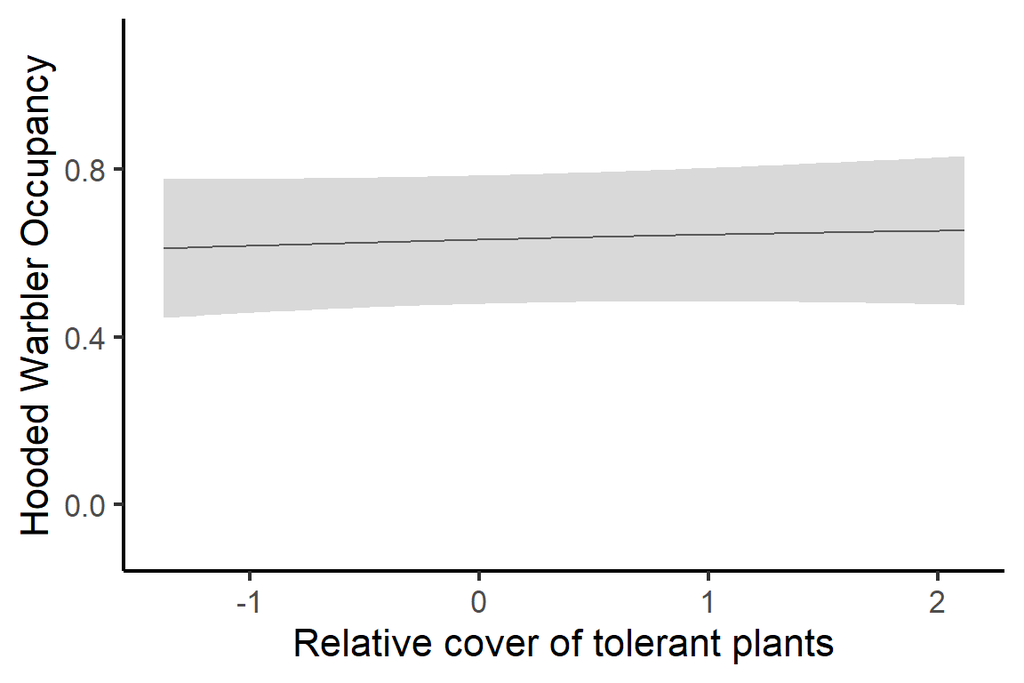

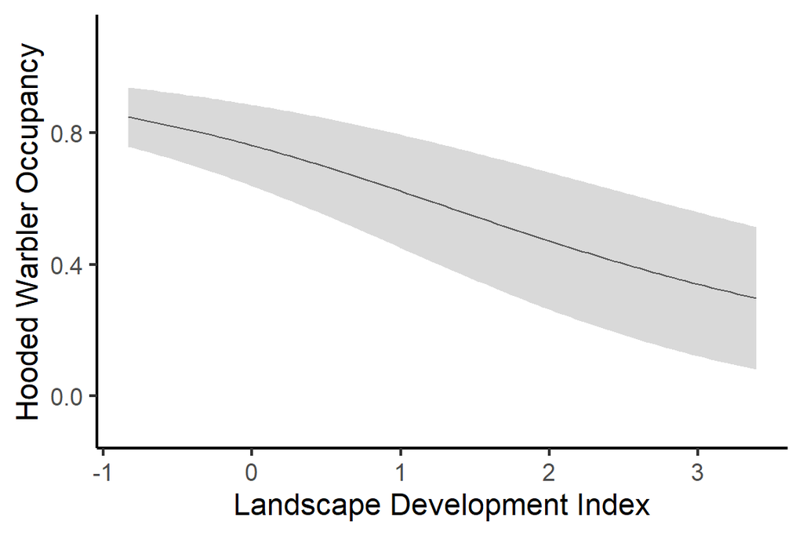

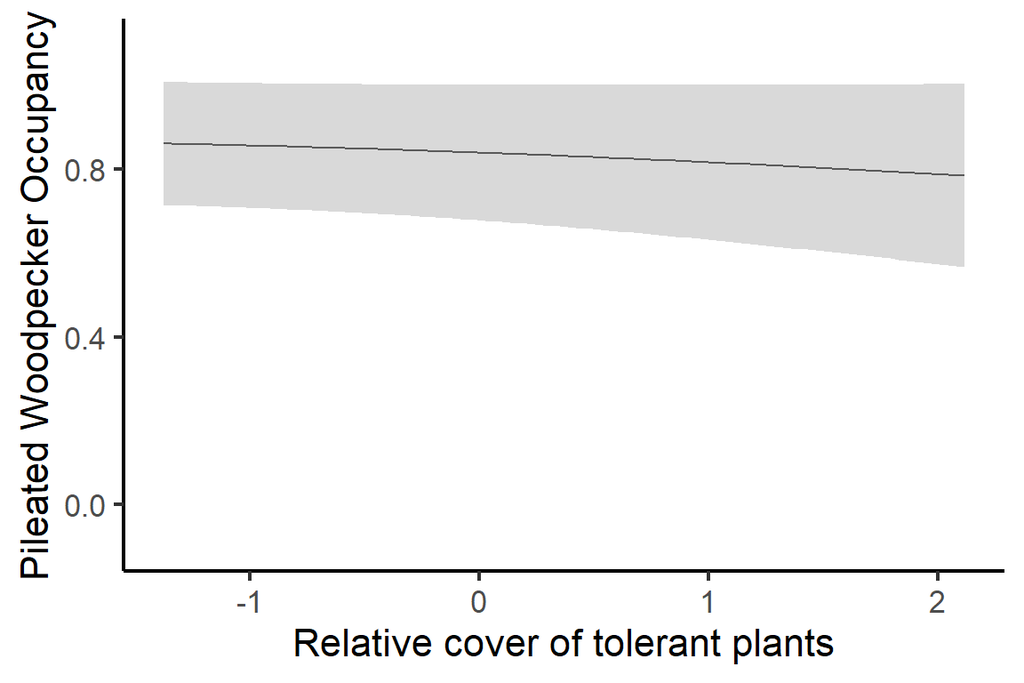

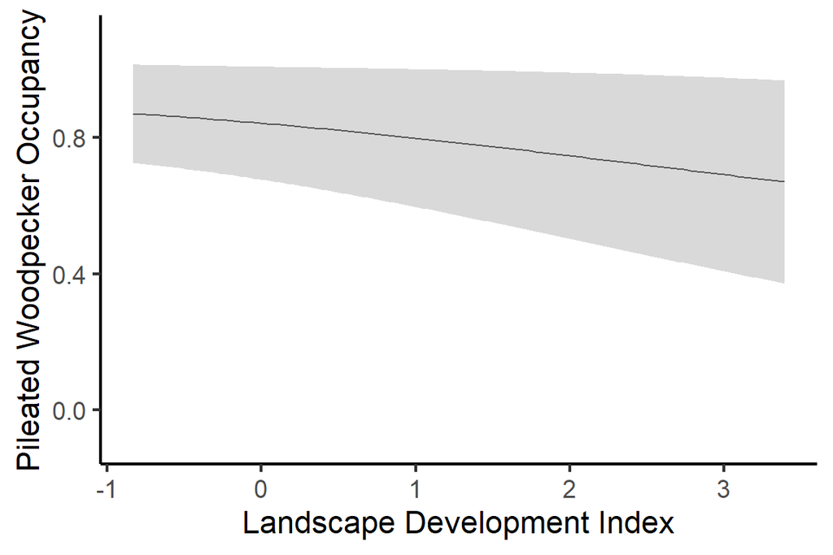

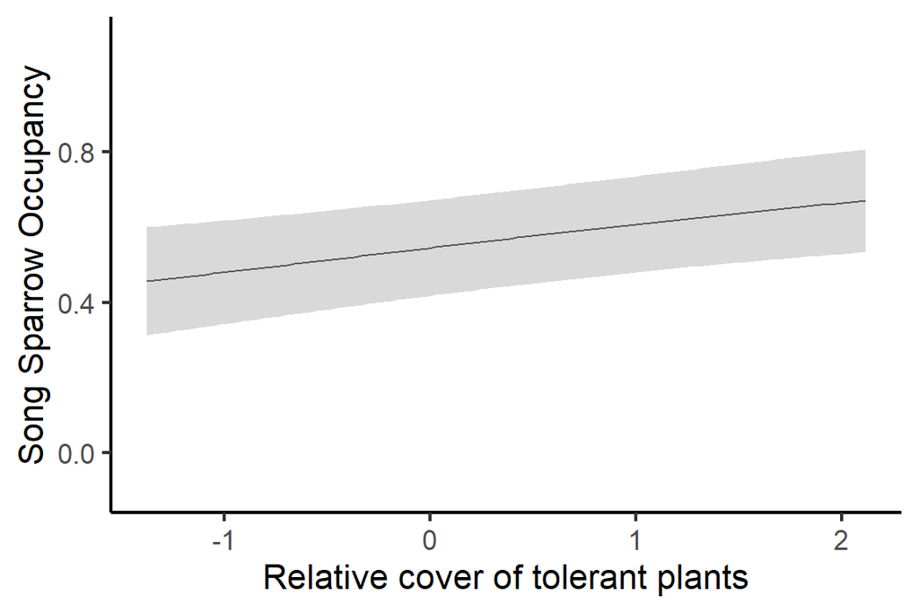

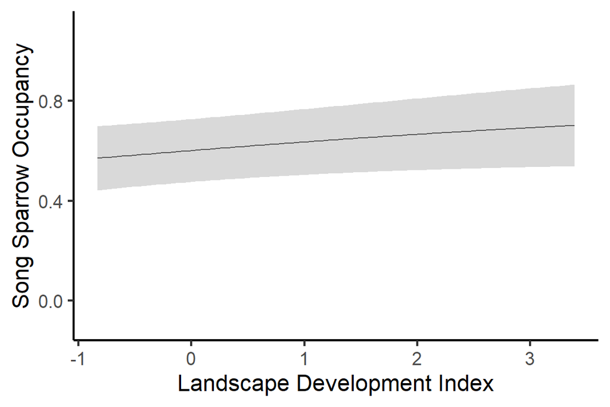

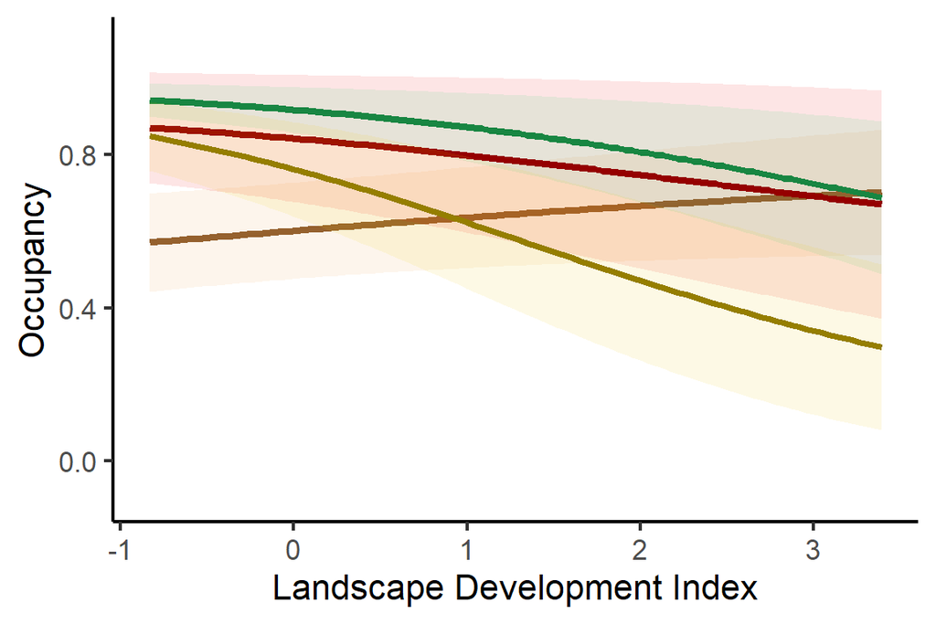

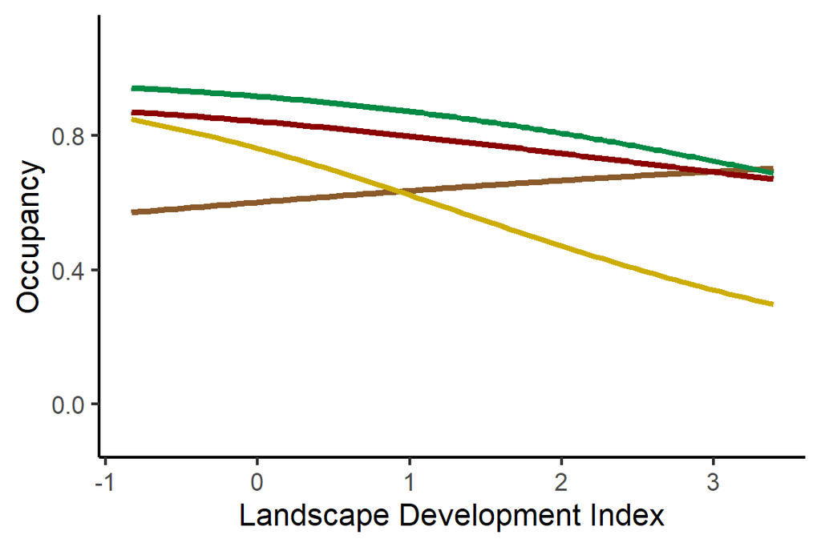

[7 more figures not shown]

### prediction overall all PCAP

```r
pcap_full<-read.csv("G:/NaturalResources/Byer/datasets/BBS/bbs_covariates.csv",header=T)

names(pcap_full)[names(pcap_full) == 'Plot.ID'] <- 'simp_plot'

pcap_full_land<-left_join(pcap_full,pcap_1styear_landscape,by="simp_plot")

pcap_full_land[is.na(pcap_full_land)] <- 0


monocots = (pcap_full_land$monocots - mean(bbs_occobject_three$occ.covs[, 20])) / sd(bbs_occobject_three$occ.covs[, 20])
perc_open = (pcap_full_land$percent_open - mean(bbs_occobject_three$occ.covs[, 21])) / sd(bbs_occobject_three$occ.covs[, 21])
developed.x = (pcap_full_land$developed.x - mean(bbs_occobject_three$occ.covs[, 11])) / sd(bbs_occobject_three$occ.covs[, 11])
ldi = (pcap_full_land$ldi - mean(bbs_occobject_three$occ.covs[, 12])) / sd(bbs_occobject_three$occ.covs[, 12])
dicot = (pcap_full_land$dicot - mean(bbs_occobject_three$occ.covs[, 3])) / sd(bbs_occobject_three$occ.covs[, 3])
carex = (pcap_full_land$carex - mean(bbs_occobject_three$occ.covs[, 2])) / sd(bbs_occobject_three$occ.covs[, 2])
tolerant = (pcap_full_land$tolerant - mean(bbs_occobject_three$occ.covs[, 10])) / sd(bbs_occobject_three$occ.covs[, 10])
canopy_dens = (pcap_full_land$canopy_dens - mean(bbs_occobject_three$occ.covs[, 17])) / sd(bbs_occobject_three$occ.covs[, 17])
svp = (pcap_full_land$svp - mean(bbs_occobject_three$occ.covs[,7])) / sd(bbs_occobject_three$occ.covs[,7])

predict_data<-data.frame(int = 1, monocots = monocots, perc_open = perc_open, developed.x = developed.x,
                         ldi = ldi, dicot = dicot, carex = carex, tol_rel = tolerant, canopy_dens = canopy_dens, svp = svp)


fullpcappred<-predict(out.ms.landvegrda_2,as.matrix(predict_data))

RMSE <- function(observed, predicted) {
  sqrt(mean((predicted - observed)^2, na.rm=TRUE))
}
f1 <- function(x, test, train) {
  nmx <- x[1]
  idp <- x[2]
  if (nmx < 1) return(Inf)
  if (idp < .001) return(Inf)
  m <- gstat(formula=mean.psi~1, locations=train, nmax=nmx, set=list(idp=idp))
  p <- predict(m, newdata=test, debug.level=0)$var1.pred
  RMSE(test$mean.psi, p)
}

set.seed(12345)


respoly<-readOGR("G:/NaturalResources/Byer/DataAnalysis/bbs_cmp_analyses/bbsapp/CMPboundaries.shp")

fullpcaprasters<-list()

for(i in 1:length(sppnames)){
  plot.dat.ms <- data.frame(x = pcap_full_land$xcoord,
                            y = pcap_full_land$ycoord,
                            mean.psi = apply(fullpcappred$psi.0.samples[,i,], 2, mean),
                            sd.psi = apply(fullpcappred$psi.0.samples[,i,], 2, sd),
                            stringsAsFactors = FALSE)

  dsp <- SpatialPoints(plot.dat.ms[,1:2])
  dsp <- SpatialPointsDataFrame(dsp, plot.dat.ms)
  crs(dsp)<-"+proj=lcc +lat_0=39.6666666666667 +lon_0=-82.5 +lat_1=41.7 +lat_2=40.4333333333333 +x_0=600000 +y_0=0 +datum=NAD83 +units=us-ft +no_defs"
  j <- sample(nrow(dsp), 0.2 * nrow(dsp))
  tst <- dsp[j,]
  trn <- dsp[-j,]
  #opt <- optim(c(8, .5), f1, test=tst, train=trn)
  # define groups for mapping
  #cuts <- c(0,0.25,0.75,1.0)
  # set up a palette of interpolated colors
  #blues <- colorRampPalette(c('yellow', 'orange', 'blue', 'dark blue'))
  #spplot(dsp, 'mean.psi', cuts=cuts, col.regions=blues(5), pch=20, cex=2)
  #v <- voronoi(dsp)

  #ch <- chull(plot.dat.ms[,1:2])
  #coords <- plot.dat.ms[c(ch, ch[1]), 1:2]  # closed polygon

  #plot(plot.dat.ms[,1:2], pch=19)
  #lines(coords, col="#E69F00" )



  #sp_poly <- SpatialPolygons(list(Polygons(list(Polygon(coords)), ID=1)))
  # set coordinate reference system with SpatialPolygons(..., proj4string=CRS(...))
  # e.g. CRS("+proj=longlat +datum=WGS84")
  #sp_poly_df <- SpatialPolygonsDataFrame(sp_poly, data=data.frame(ID=1))
  #writeOGR(sp_poly_df, "chull", layer="chull", driver="ESRI Shapefile")

  #vca <- intersect(v, respoly)
  #spplot(vca, 'mean.psi', col.regions=rev(get_col_regions()))
  #r <- raster(respoly, res=500)
  #crs(r)<-"+proj=lcc +lat_0=39.6666666666667 +lon_0=-82.5 +lat_1=41.7 +lat_2=40.4333333333333 +x_0=600000 +y_0=0 +datum=NAD83 +units=us-ft +no_defs"
  #crs(vca)<-"+proj=lcc +lat_0=39.6666666666667 +lon_0=-82.5 +lat_1=41.7 +lat_2=40.4333333333333 +x_0=600000 +y_0=0 +datum=NAD83 +units=us-ft +no_defs"
  #vr <- rasterize(vca, r, 'mean.psi')
  #crs(vr)<-"+proj=lcc +lat_0=39.6666666666667 +lon_0=-82.5 +lat_1=41.7 +lat_2=40.4333333333333 +x_0=600000 +y_0=0 +datum=NAD83 +units=us-ft +no_defs"
  #plot(vr)
  #points(dsp)

  fitmax <- gstat::gstat(formula = mean.psi ~ 1, data = dsp, nmax = opt$par[1], set = list(idp = opt$par[2]))
  maxint <- raster::interpolate(r, model=fitmax)
  crs(maxint)<-"+proj=lcc +lat_0=39.6666666666667 +lon_0=-82.5 +lat_1=41.7 +lat_2=40.4333333333333 +x_0=600000 +y_0=0 +datum=NAD83 +units=us-ft +no_defs"
  plot(maxint, col=rev(heat.colors(255)))
  plot(vr, add=TRUE)
  r2 <- crop(maxint, extent(respoly))
  r3 <- mask(r2, respoly)
  fullpcaprasters[[i]]<-r3
  writeRaster(r3,filename = paste0("U:/DataAnalysis/BreedingBirds/01132023predictions/",sppnames[i],"_occmeanpsi_landvegrda_2_fullpcap_nni_opt_clipped.asc"),overwrite=TRUE)

}

saveRDS(fullpcaprasters,"G:/NaturalResources/Byer/datasets/BBS/fullpcaprasters_occ.Rdata")



#first import all files in a single folder as a list
#rastlist <- list.files(path = "G:/NaturalResources/Byer/datasets/BBS/rasterpredictions/nni_opt/clipped", pattern='.asc$',
#all.files=TRUE, full.names=TRUE)

#import all raster files in folder using lapply
#allrasters <- lapply(rastlist, raster)

#to check the index numbers of all imported raster list elements
#allrasters

#call single raster element
#allrasters[[1]]

#to run a function on an individual raster e.g., plot
#plot(allrasters[[1]])

#saveRDS(allrasters,"G:/NaturalResources/Byer/datasets/BBS/rasterpredictions/nni_opt/clipped/nnirasters_fullpcap.RData")

rich.pred<-apply(fullpcappred$z.0.samples, c(1,3), sum)
rich.pred.R<-apply(fullpcappred$z.0.samples[,c(9,14,27,37,48,51,54,55,63,69,75,77,78,85,88,93,96),], c(1,3), sum)
rich.pred.S<-apply(fullpcappred$z.0.samples[,c(3,4,5,7,8,10,15,16,17,19,21,22,26,28,30,33,34,36,38,40,41,42,44,45,46,49,50,52,57,59,61,62,64,70,73,74,79,80,82,83,86,89,91,97,98),], c(1,3), sum)
rich.pred.T<-apply(fullpcappred$z.0.samples[,c(1,2,6,11,12,13,18,20,23,24,25,29,31,32,35,39,43,47,53,56,58,60,65,66,67,68,71,72,76,81,84,87,90,92,94,95,99,100,101,102,103),], c(1,3), sum)




 plot.dat.rich <- data.frame(x = pcap_full_land$xcoord,
                            y = pcap_full_land$ycoord,
                            mean.rich = apply(rich.pred, 2, mean),
                            sd.rich = apply(rich.pred, 2, sd),
                            mean.rich.R = apply(rich.pred.R,2,mean),
                            sd.rich.R = apply(rich.pred.R,2,sd),
                            mean.rich.S = apply(rich.pred.S,2,mean),
                            sd.rich.S = apply(rich.pred.S,2,sd),
                            mean.rich.T = apply(rich.pred.T,2,mean),
                            sd.rich.T = apply(rich.pred.T,2,sd),
                            stringsAsFactors = FALSE)

 write.csv(plot.dat.rich,"plotdatarichness.csv")

  dsp <- SpatialPoints(plot.dat.rich[,1:2])
  dsp <- SpatialPointsDataFrame(dsp, plot.dat.rich)
  crs(dsp)<-"+proj=lcc +lat_0=39.6666666666667 +lon_0=-82.5 +lat_1=41.7 +lat_2=40.4333333333333 +x_0=600000 +y_0=0 +datum=NAD83 +units=us-ft +no_defs"
  j <- sample(nrow(dsp), 0.2 * nrow(dsp))
  tst <- dsp[j,]
  trn <- dsp[-j,]
RMSE <- function(observed, predicted) {
  sqrt(mean((predicted - observed)^2, na.rm=TRUE))
}
f1 <- function(x, test, train) {
  nmx <- x[1]
  idp <- x[2]
  if (nmx < 1) return(Inf)
  if (idp < .001) return(Inf)
  m <- gstat(formula=mean.rich.S~1, locations=train, nmax=nmx, set=list(idp=idp))
  p <- predict(m, newdata=test, debug.level=0)$var1.pred
  RMSE(test$mean.rich.S, p)
}
p <- data.frame(geom(dsp)[, c("x", "y")], as.data.frame(dsp))
r <- raster(respoly, res=100)
opt <- optim(c(8, 0.5), f1, test=tst, train=trn)
m <- gstat(formula=mean.rich.S~1, locations=~x+y, data=p, nmax=opt$par[1], set=list(idp=opt$par[2]))
idw <- interpolate(r, m, debug.level=0)


idw <- mask(idw, respoly)
plot(idw, 1)

writeRaster(idw,filename = paste0(getwd(),"/Birdspprichness_S_idw_01312023.asc"),overwrite=TRUE)
```